# Script6_Armbruster2026_PandeyIntegration_IntegrationClusteringAnnotation

Daniel Armbruster

2026-07-24

- In this script we performed integratation, clustering and annotation of the dataset generated in Script 5 containing cells from different samples of the whole telencephalon dataset published by Pandey and colleagues (10.1101/gr.277278.122) together with our own dataset.
- We performed differentially expressed gene analysis, identified the differenitally expressed transcription factors and generated the resulting data table that are part of Table S1D-F. Moreover we generated the visualizations of Figure 1E-F and Figure S2E-K.
- We characterized neurotransmitter and neuropeptide production and reception signatures across clusters and generated the corresponding visualizations that are part of Figure 6A and B as well as the associated data presented in Table S6F-H and Table S6M-O.
- The session info including the used packages and their versions is provided at the end of this script.

# 1. Load Packages

```r
library(Seurat)
library(dplyr)
library(openxlsx)
library(ggplot2)
library(readr)
library(tidyverse)
library(cowplot)
```

# 2. Load Data

```r
merged_seurat <- readRDS("RDS_files/Script5_Armbruster2026_Pandey_integ_filtered.rds")
```

# 3. Filter for cells with DA markers

```r
merged_seurat <- JoinLayers(merged_seurat)
merged_seurat[["RNA"]] <- as(object = merged_seurat[["RNA"]], Class = "Assay5")
merged_seurat[["RNA"]] <- split(merged_seurat[["RNA"]], f = merged_seurat$sample)
# Normalize RNA counts before marker-based filtering
merged_seurat <- NormalizeData(merged_seurat)
# Retain only cells expressing DA markers (th, slc6a3, or slc18a2)
merged_seurat_filt <- subset(merged_seurat, subset = th >= 1 | slc6a3 >= 1| slc18a2 >= 1)
```

# 4. Check for batch effects

```r
# Performing workflow to assess potential batch effects before integration.
merged_seurat_filt <- FindVariableFeatures(merged_seurat_filt)
```

```
## Finding variable features for layer counts.15dpf_b1
```

```
## Finding variable features for layer counts.15dpf_b2
```

```
## Finding variable features for layer counts.15dpf_b3
```

```
## Finding variable features for layer counts.15dpf_b4
```

```
## Finding variable features for layer counts.6dpf_b1
```

```
## Finding variable features for layer counts.6dpf_b2
```

```
## Finding variable features for layer counts.6dpf_b3
```

```
## Finding variable features for layer counts.6dpf_b4
```

```
## Finding variable features for layer counts.6dpf_b5
```

```
## Finding variable features for layer counts.6dpf_b6
```

```
## Finding variable features for layer counts.6dpf_b7
```

```
## Finding variable features for layer counts.6dpf_b8
```

```
## Finding variable features for layer counts.Adult_b1_1
```

```
## Finding variable features for layer counts.Adult_b1_2
```

```
## Finding variable features for layer counts.Adult_b2_1
```

```
## Finding variable features for layer counts.Adult_b2_2
```

```
## Finding variable features for layer counts.GFP+_sort
```

```r
merged_seurat_filt <- ScaleData(merged_seurat_filt)
merged_seurat_filt <- RunPCA(merged_seurat_filt)
```

```
## PC_ 1
## Positive:  opn1sw1, sv2a, cacna2d2a, kidins220b, aplp1, gpm6aa, ank2b, slc6a1b, pcloa, hspa4a
##     clstn1, kif1b, dnajb1b, nova2, atp1a3a, grin1b, clk4a, hsp90b1, ptprz1b, adcyap1r1a
##     aplp2, kif1aa, atp2b1a, atp2b3a, nrxn2b, syt1a, nr1d2a, tmem178b, gramd4a, msi2b
## Negative:  mt-atp6, mt-co2, mt-co1, oaz1b, calm3b, oaz1a, gabarapb, mt-nd1, cdc42, dynll1
##     sumo3a, fkbp1aa, rpl32, rpl7, gng3, cox6c, rpl36, egr4, rps26, fosab
##     rps15a, brk1, rpl11, RPL41, cycsb, rpl3, gapdhs, higd1a, rps19, mllt11
## PC_ 2
## Positive:  tmsb, elavl4, uba52, rpl14, ppm1aa, nova2, hsp90ab1, gnb1a, dpysl3, eef1g
##     ywhah, rpl31, marcksl1a, jpt1b, atrx, gnao1a, ank2b, cd99l2, rps17, zfhx4
##     id4, map1aa, rpl9, rpl17, tuba1c, eef2b, pcloa, taf3, rps27a, opn1sw1
## Negative:  CR383676.1, mt-co2, egr4, nrgna, mt-atp6, zgc:122979, egr1, synpr, mt-co1, sp8a
##     mt-nd1, mdkb, gadd45ba, trim9, fosab, ENSDARG00000043673, junbb, sst3, iqsec2b, AC024175.4
##     fkbp1b, ier2a, junba, calm3b, arpp21, pyyb, fam107b, mcl1a, ENSDARG00000068274, glula
## PC_ 3
## Positive:  slc6a1b, mdkb, slc32a1, adcyap1r1a, gad1b, stxbp1a, syn2a, sncb, atp6v0cb, basp1
##     slc38a3a, ywhaqb, synpr, kcnip1b, sh3gl2a, gpm6aa, nsfa, atp6ap2, pcp4l1, znf385c
##     fam184b, camk2b1, iqsec2b, pgk1, sv2a, atp1a3a, htra1b, sst3, fkbp1b, marcksl1b
## Negative:  insm1b, CR318588.4, rpsa, RPL41, rps19, rpl26, tpt1, CR383676.1, rpl3, rpl29
##     lhx1a, rplp0, arg2, rplp2l, rps6, rps15a, rpl22, nudt5, rplp1, rps26
##     rps7, six3b, rpl32, rps17, b2m, rps16, rpl24, rpl39, rgs5a, rpl18a
## PC_ 4
## Positive:  h3f3b.1, synpr, si:ch73-281n10.2, h3f3a, ybx1, ptmaa, tubb2b, si:ch73-1a9.3, hmgb3a, hsp70.1
##     cirbpb, h3f3d, pyyb, arpp21, hmgb2b, sst3, sp8a, atp1b3a, hmga1a, vdac3
##     mt2, ewsr1a, hnrnpaba, histh1l, syn2a, mdkb, rplp1, tubb5, dlx5a, bzw1a
## Negative:  sncgb, CR318588.4, uchl1, zgc:114118, fosb, b2m, ndrg3a, spock3, atp1b1b, ENSDARG00000079307
##     tspan18a, clstn1, btg2, itm2cb, rab41, nr4a1, plekhb2, map1ab, arg2, kif1aa
##     CR383676.1, pkib, camkvb, tmsb2, aplp1, pabpc1b, ppp1r15a, atp2b4, capns1b, atp1a3a
## PC_ 5
## Positive:  nxph1, chodl, synpr, scg2b, insm1b, sik2b, sst3, sipa1l2, rgs5a, htra1b
##     slc38a3a, th, syngr3b, usp6nl, dhrsx, ptprna, mt2, xbp1, syn2a, dnajb4
##     lhx1a, hsp90aa1.2, pyyb, six3b, gad2, slc6a1b, dlx2a, itm2ba, spock3, si:dkey-175g6.2
## Negative:  calm3a, palmdb, cpne4a, rbfox1, nr2f1a, syt1a, pcp4a, c1qtnf4, necab1, zgc:114118
##     ywhaqa, npas4b, six3a, camk2n1a, ppp3cb, sox11b, hmgb3a, cdh8, rprml, atp2b4
##     dynll2a, cox6b1, tuba1c, grin1a, gpm6ab, SMIM18, ndufa4, ptmaa, nfkbiab, tmsb2
```

```r
merged_seurat_filt <- FindNeighbors(merged_seurat_filt, dims = 1:20)
merged_seurat_filt <- FindClusters(merged_seurat_filt)
```

```
## Modularity Optimizer version 1.3.0 by Ludo Waltman and Nees Jan van Eck
##
## Number of nodes: 340
## Number of edges: 11986
##
## Running Louvain algorithm...
## Maximum modularity in 10 random starts: 0.7001
## Number of communities: 5
## Elapsed time: 0 seconds
```

```r
merged_seurat_filt <- RunUMAP(merged_seurat_filt, dims = 1:20, reduction.name = "umap.unintegrated", seed.use = 45)
```

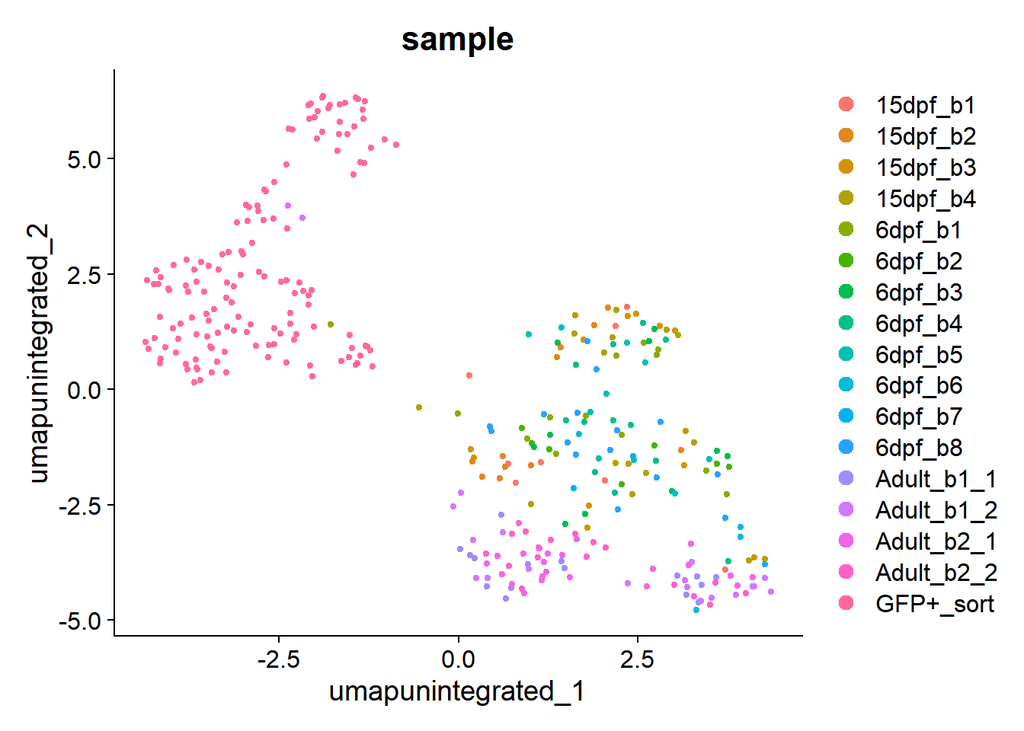

```r
DimPlot(merged_seurat_filt, group.by = "sample", reduction = "umap.unintegrated")
```

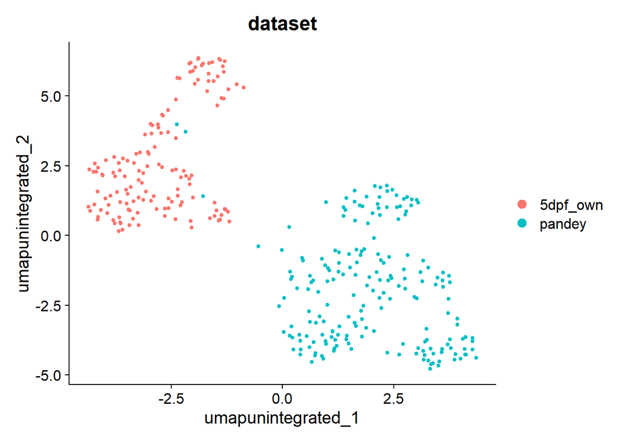

```r
DimPlot(merged_seurat_filt, group.by = "dataset", reduction = "umap.unintegrated")
```

- Unintegrated UMAP shows that clustering is driven by the sample and dataset origin of the cells.

# 5. Integration

```r
# Performing Harmony integration to reduce sample/dataset variation
merged_seurat_filt <- IntegrateLayers(
  object = merged_seurat_filt, method = HarmonyIntegration,
  orig.reduction = "pca", new.reduction = "harmony",
  verbose = FALSE
)
```

```
## The `features` argument is ignored by `HarmonyIntegration`.
```

```r
# Join for downstream analysis steps.
merged_seurat_filt <- JoinLayers(merged_seurat_filt)
```

- Clustering / Dim reduction

```r
# Clustering and UMAP visualization based on the first 30 dimensions
merged_seurat_filt <- FindNeighbors(merged_seurat_filt, reduction = "harmony", dims = 1:30)
merged_seurat_filt <- FindClusters(merged_seurat_filt, resolution = 1.0, cluster.name = "harmony_clusters")
```

```
## Modularity Optimizer version 1.3.0 by Ludo Waltman and Nees Jan van Eck
##
## Number of nodes: 340
## Number of edges: 11347
##
## Running Louvain algorithm...
## Maximum modularity in 10 random starts: 0.7210
## Number of communities: 7
## Elapsed time: 0 seconds
```

```r
merged_seurat_filt <- RunUMAP(merged_seurat_filt, reduction = "harmony", dims = 1:30, reduction.name = "umap.harmony", seed.use = 42)
```

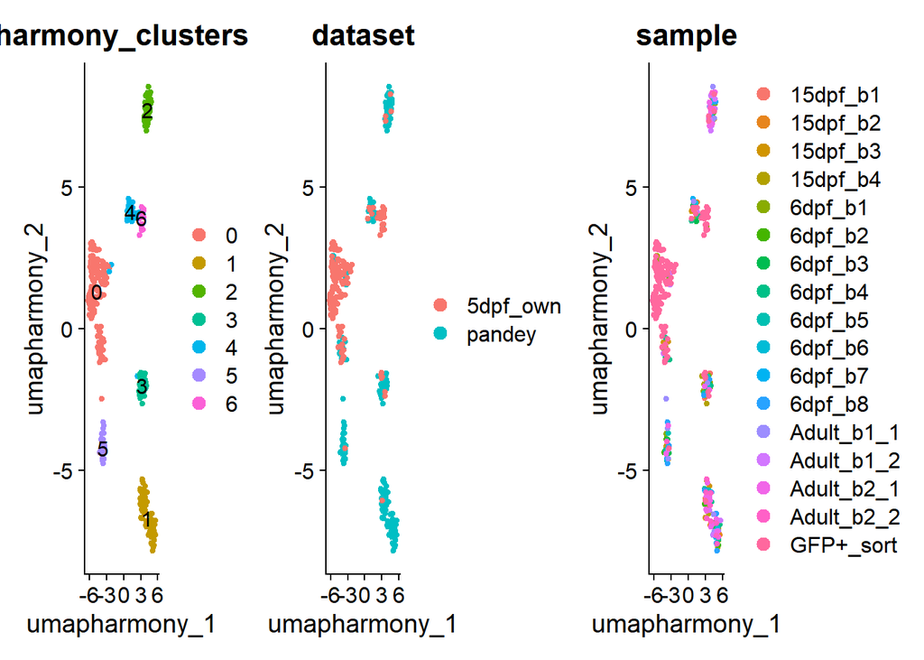

```r
DimPlot(merged_seurat_filt, reduction = "umap.harmony", group.by = "harmony_clusters", label=T) | DimPlot(merged_seurat_filt, reduction = "umap.harmony", group.by = "dataset") | DimPlot(merged_seurat_filt, reduction = "umap.harmony", group.by = "sample")
```

- The integrated UMAP still shows some dataset-driven separation. Low cell numbers of individual samples might also affect integration performance. However, we will evaluate if clustering was driven by true biological differences in the composition of both datasets based makrer gene expression of the obtained clusters.

# 6. Annotation

- Prior to annotation we performed DEG analysis (not included in this script) to identify cluster-specific genes. Using these results together with knowledge from previously published data we assigned the cluster identities.
- We used different visualizations for gene expression of such marker genes to evaluate the identities of obtained clusters.
- After annotation we repeated DEG analysis (see section 7) to acquire the data Table S1E is based on.

## 6.1 CA marker expression and cluster size

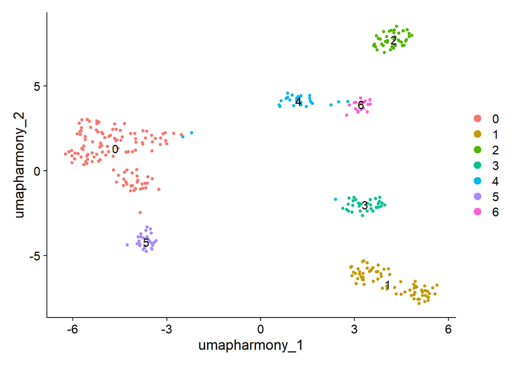

```r
DimPlot(merged_seurat_filt, reduction = "umap.harmony", label = T)
```

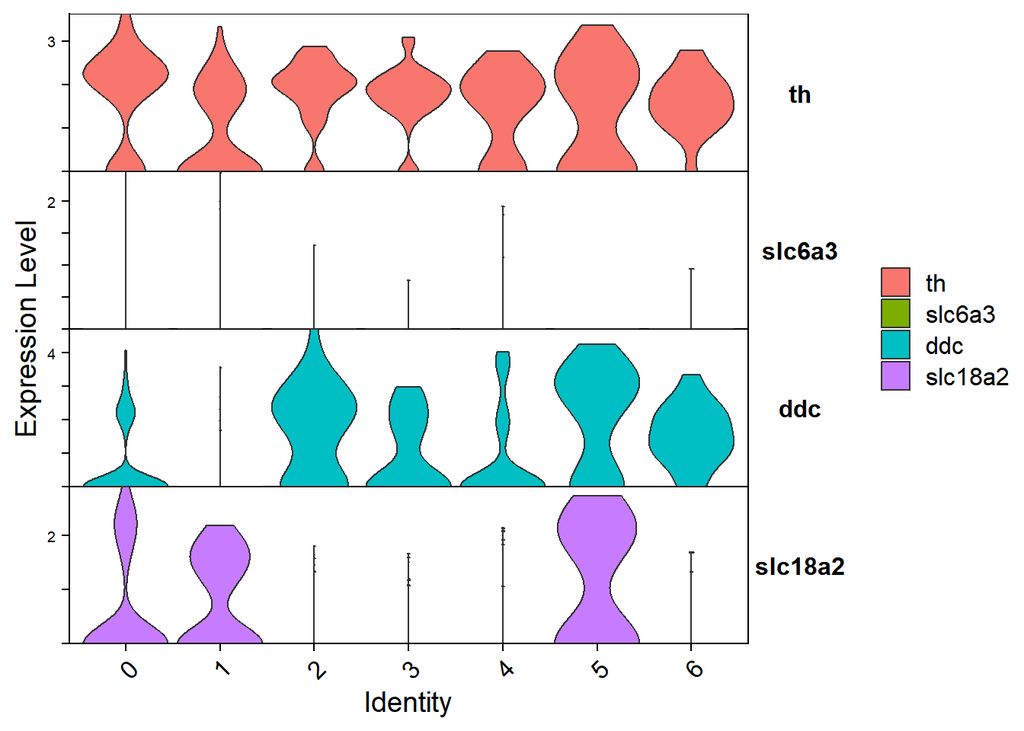

```r
VlnPlot(merged_seurat_filt, c("th","slc6a3", "ddc", "slc18a2"), group.by = "harmony_clusters", stack = T, flip = T)
```

```r
n_cells <- FetchData(merged_seurat_filt,
                     vars = c("ident", "orig.ident")) %>% dplyr::count(ident, orig.ident) %>% tidyr::spread(ident,n)
n_cells
```

```
##      orig.ident   0  1  2  3  4  5  6
## 1 SeuratProject 122 70 41 32 30 27 18
```

## 6.2 Olfactory bulb (OB) and extended medial amygdala (EMeA)

- Cluster 3 expresses genes previously detected in the olfactory bulb including etv1, dlx2a, dlx5a and sst3 ( (Filippi et al., 2012; 10.1016/j.ydbio.2012.06.010; Armbruster et al., 2025; 10.1002/cne.70079) together with synpr. Our coexpression analysis identified synpr as marker expressed by olfactory bulb DA neurons.
- In contrast cluster 5 expresses dlx2a, dlx5a and sst3 together with the highly enriched calcium binding protein encoding gene cpne4a. As sst3 and dlx2a are also expressed by extended medial amygdala DA neurons (Armbruster et al., 2025; 10.1002/cne.70079) and our coexpression analysis of cpne4a revealed its expression in these cells, cluster 5 likely represent EMeA DA cells.
- Additionally we could detect expression of calb2a in cluster 5 further confirming its EMeA identity (Armbruster et al., 2025; 10.1002/cne.70079)
- Label: cl3 = OB, cl5 = EMeA

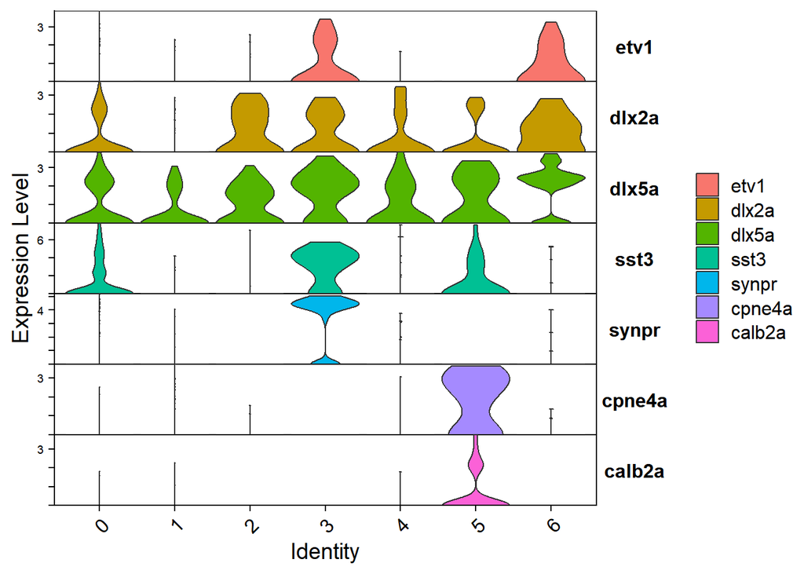

```r
VlnPlot(merged_seurat_filt, c("etv1", "dlx2a", "dlx5a", "sst3","synpr", "cpne4a", "calb2a"), group.by = "harmony_clusters", stack = T, flip = T)
```

## 6.3 PoA-PTh (Cluster 6)

- Several markers expressed in the preoptic area (PoA) of zebrafish, including arxa, dlx2a, dlx5a, pou3f2b, six3a, nr4a2a and nr4a2b are expressed in this cluster (Filippi et al., 2012; 10.1016/j.ydbio.2012.06.010) However, the cluster also shows prethalamic (PTh) markers such as meis2a and isl1.
- Therefore, this cluster may represent a mixed population of cells originating from the preoptic area and prethalamus.
- Label: cl6 = PoA-PTh

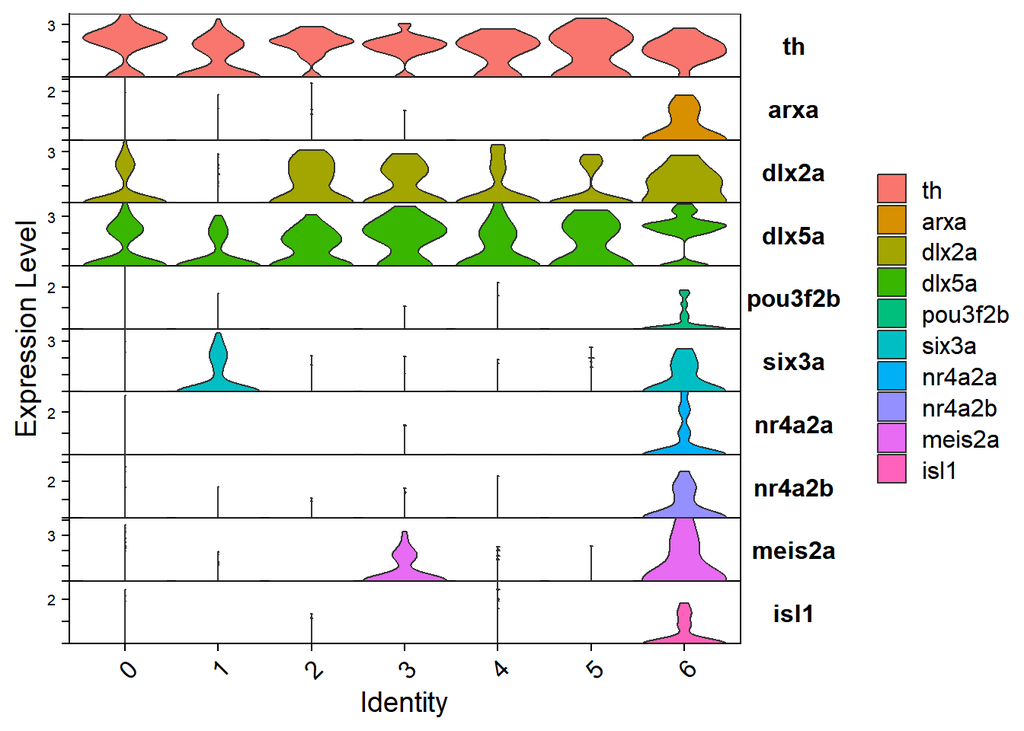

```r
VlnPlot(merged_seurat_filt, c("th", "arxa", "dlx2a","dlx5a", "pou3f2b", "six3a", "nr4a2a", "nr4a2b", "meis2a", "isl1"), group.by = "harmony_clusters", stack = T, flip = T)
```

## 6.4 Prethalamus (Cluster 0)

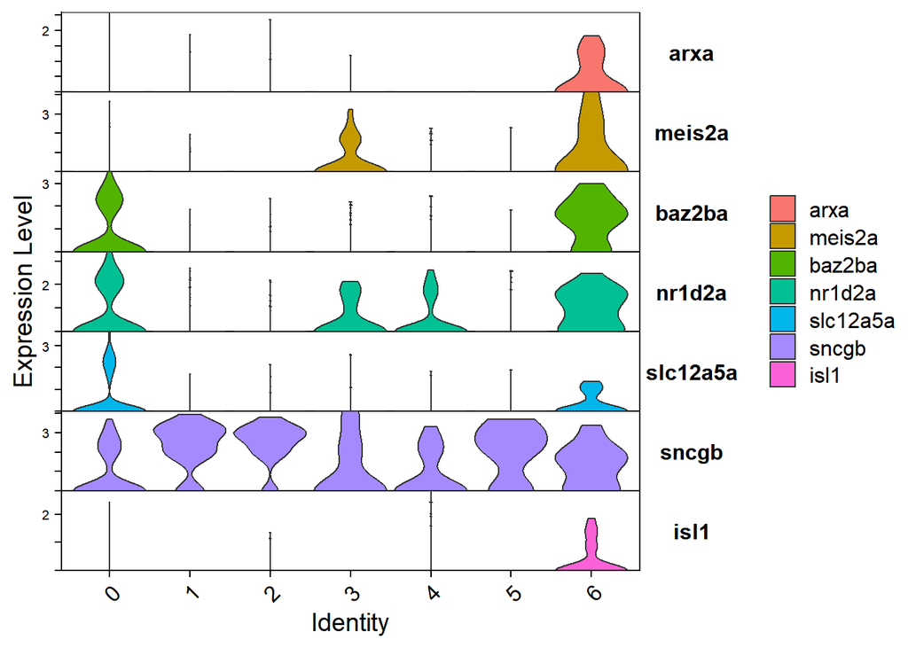

```r
VlnPlot(merged_seurat_filt, c("arxa", "meis2a", "baz2ba", "nr1d2a", "meis2a", "slc12a5a", "sncgb", "isl1"), group.by = "harmony_clusters", stack = T, flip = T)
```

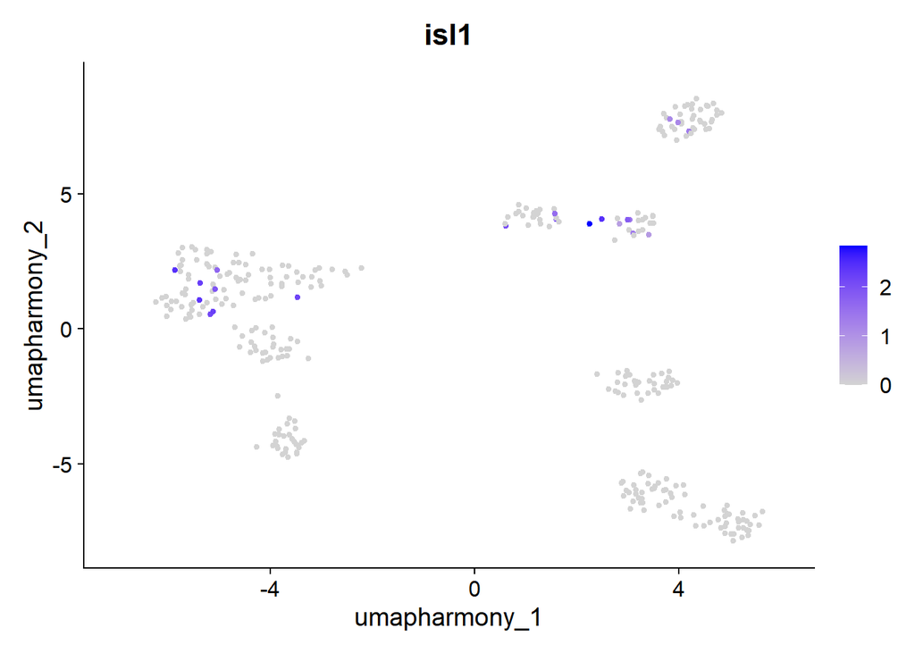

```r
FeaturePlot(merged_seurat_filt, "isl1", reduction = "umap.harmony")
```

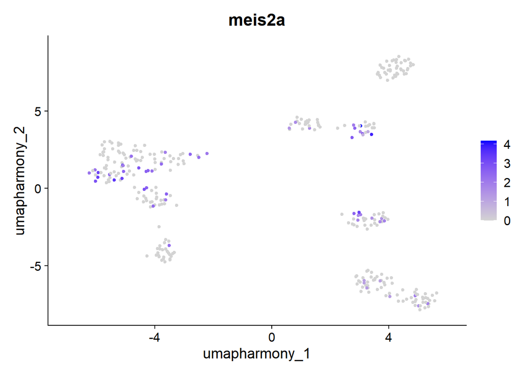

```r
FeaturePlot(merged_seurat_filt, "meis2a", reduction = "umap.harmony")
```

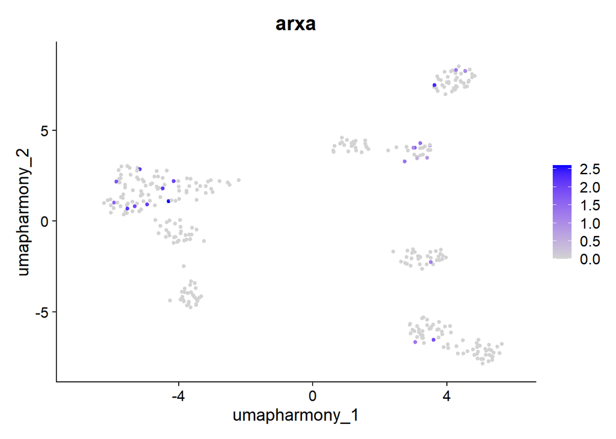

```r
FeaturePlot(merged_seurat_filt, "arxa", reduction = "umap.harmony")
```

## 6.5 PoA (Cluster 2)

- Genes differentially expressed in cluster 2 include insm1b, esr1, satb2, mef2ca, six3b and lhx1a.
- Some of these markers (e.g. six3b and lhx1a) appear to be expressed in the PoA / prethalamic area based on gene expression patterns deposited on the larval zebrafish standard brain atlas on mapzebrain.org. In addition, this cluster expresses th2, described for a subpopulation of zebrafish preoptic area DA neurons (Filippi et al., 2010; DOI:10.1002/cne.22213).
- Thus, we annotated this cluster as PoA.
- Label: cl2 = PoA

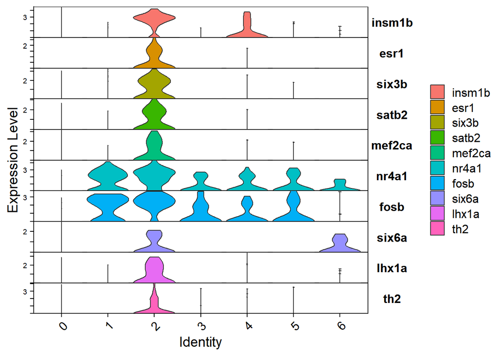

```r
VlnPlot(merged_seurat_filt, c("insm1b","esr1","six3b","satb2","mef2ca","nr4a1","fosb","six6a","lhx1a", "th2"), group.by = "harmony_clusters", stack = T, flip = T)
```

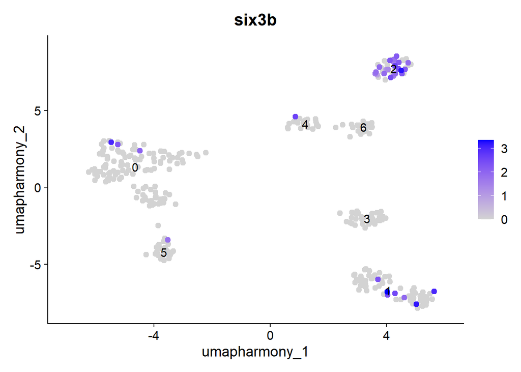

```r
FeaturePlot(merged_seurat_filt, features = "six3b", label = T,reduction = "umap.harmony", pt.size = 2, order = T)
```

## 6.6 Unspecific ventral forebrain cluster

- We could not define it as a previously described DA cluster nor to a specific anatomical region.
- Based on its expression of th, dlx5a and foxg1a expression, it is likely a DA cluster in the ventral forebrain and will be annotated as vFB cluster.
- Label: cl1 = vFb

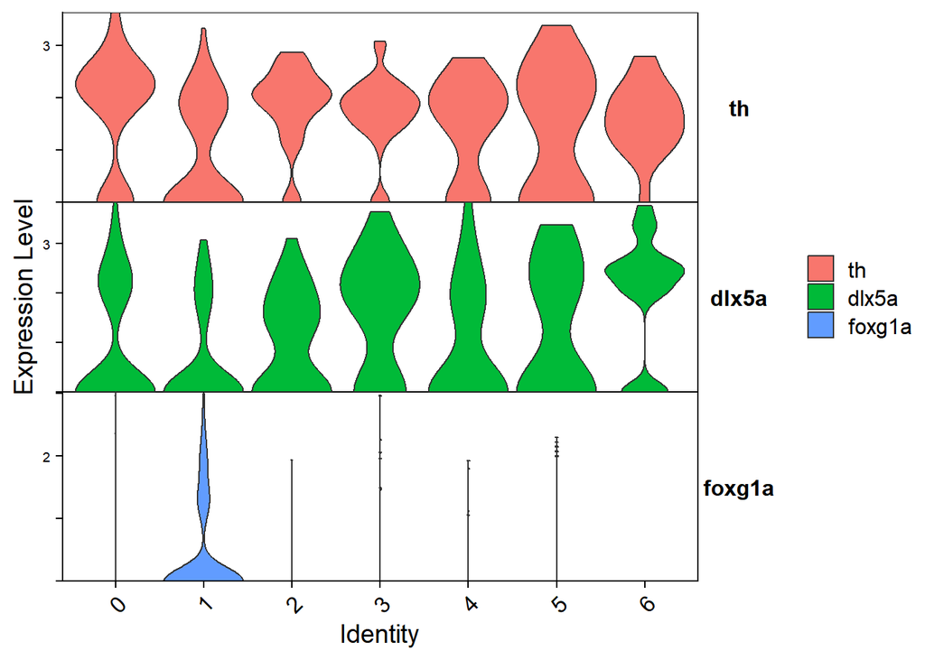

```r
# Harmony
VlnPlot(merged_seurat_filt, c("th","dlx5a", "foxg1a"), group.by = "harmony_clusters", stack = T, flip = T)
```

## 6.7 Hyp

- Cluster 4 showed relatively unspecific gene expression patterns. However, a subset of cells within this cluster expressed hypothalamic marker genes, including *th2*, *nkx2.4a*, *nkx2.4b*, and *prox1*, suggesting the presence of hypothalamic cells (Filippi et al., 2012; 10.1016/j.ydbio.2012.06.010)
- Label cl4 = Hyp

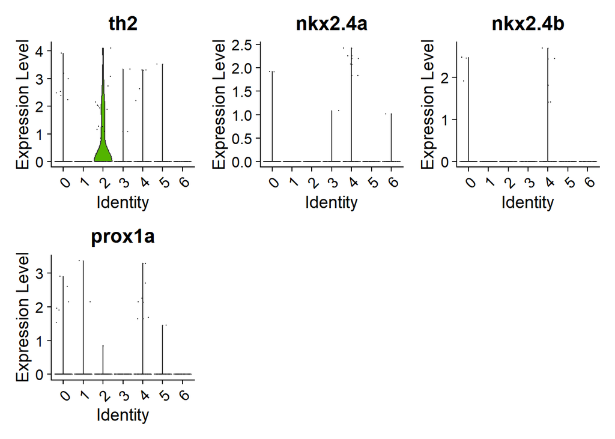

```r
VlnPlot(merged_seurat_filt, features = c("th2", "nkx2.4a", "nkx2.4b", "prox1a"))
```

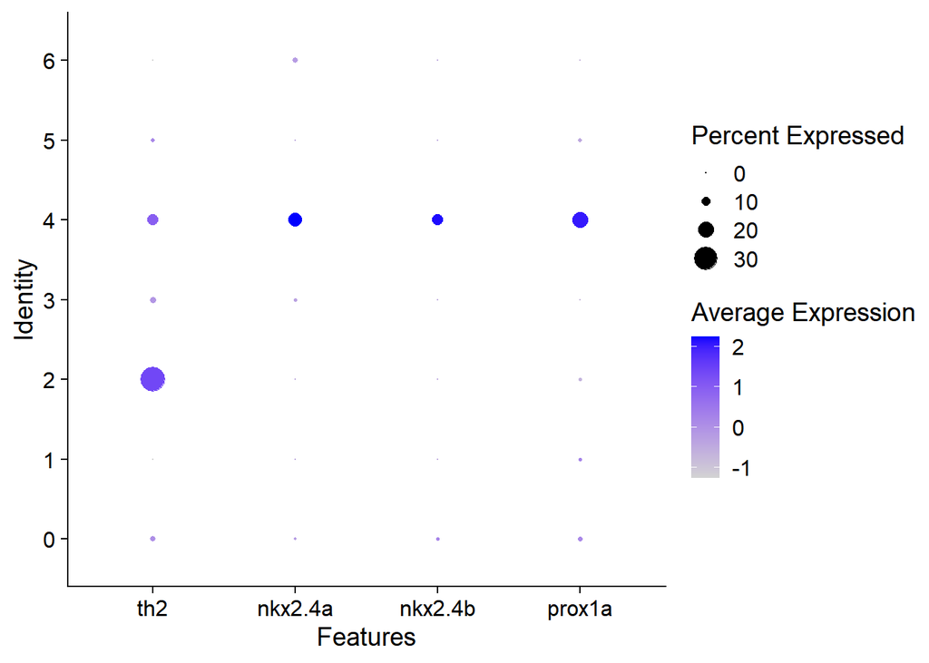

```r
DotPlot(merged_seurat_filt, c("th2", "nkx2.4a", "nkx2.4b", "prox1a"))
```

## 6.8 Annotate clusters

- Cluster identities were assigned based on marker gene expression analysis above.

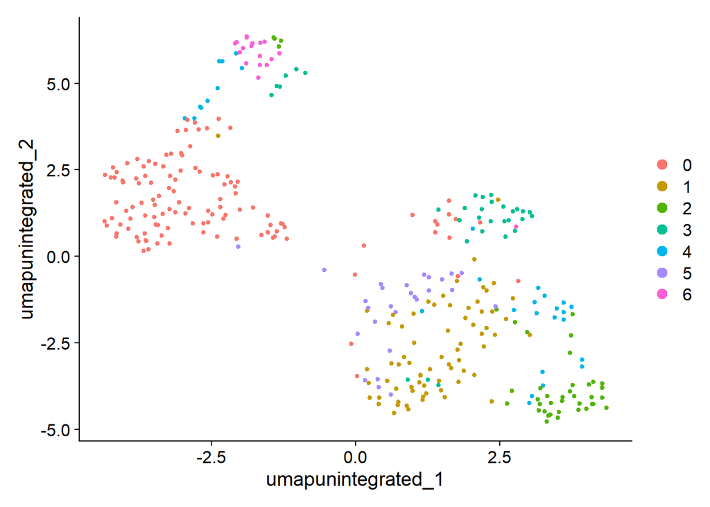

```r
DimPlot(merged_seurat_filt)
```

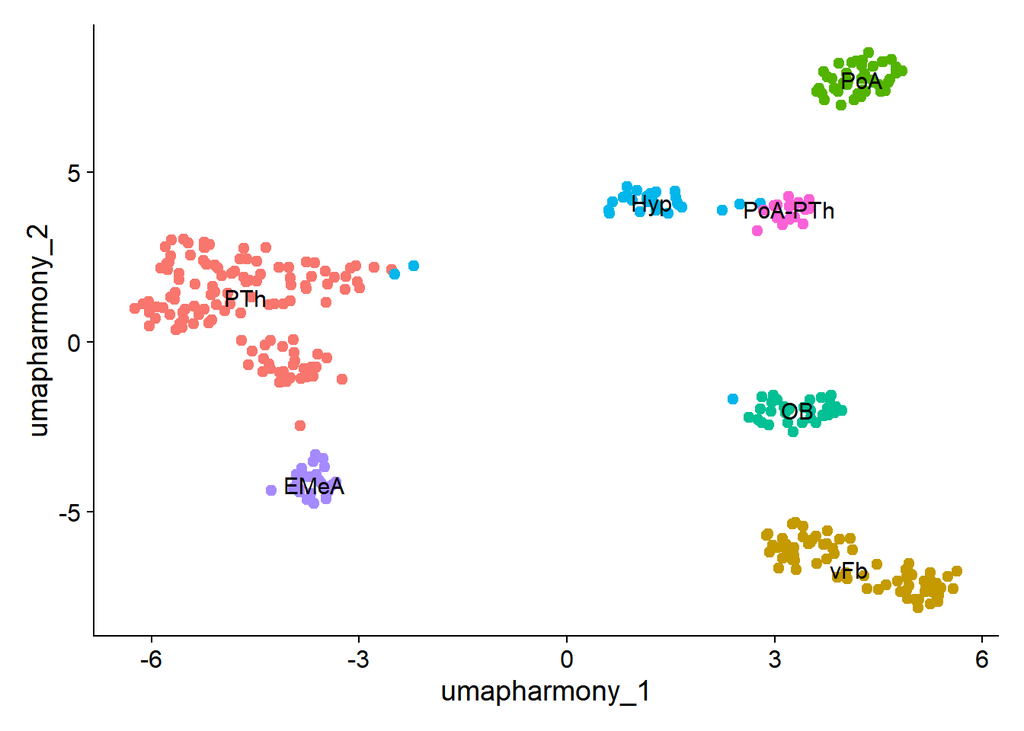

```r
merged_seurat_annot <- RenameIdents(merged_seurat_filt, "0" = "PTh", "1" = "vFb", "2" = "PoA", "3" = "OB", "4" = "Hyp", "5" = "EMeA", "6" = "PoA-PTh")
merged_seurat_annot$annotation <- merged_seurat_annot@active.ident
DimPlot(merged_seurat_annot,  reduction = "umap.harmony", label = T, pt.size = 2) + NoLegend()
```

## 6.9 Save / Read annotated dataset

```r
saveRDS(merged_seurat_annot, "RDS_files/Script6_Armbruster2026_integ_annot.rds")

merged_seurat_annot <-readRDS("RDS_files/Script6_Armbruster2026_integ_annot.rds")
```

# 7. DEG Analysis of annotated object

- To identify cluster-specific genes DEG analysis was performed on the annotated Seurat object. Only positively enriched genes expressed in at least 20% of cells with a log2FC of at least 0.25 and a adjusted p-value < 0.05 were considered as cluster specific.

```r
# Calculate DEGs and generate dataframes for all DEGs and TF DEGs
norm_markers_merge_seurat <- FindAllMarkers(merged_seurat_annot, only.pos = TRUE, min.pct = 0.2, logfc.threshold = .25)
```

[output not shown]

```r
# Only include DEGs with adjusted p-value < 0.05
try(norm_markers_merge_seurat <- dplyr::filter(norm_markers_merge_seurat, p_val_adj <= 0.05))

# Sort by avg_log2FC
norm_markers_merge_seurat_sorted <- norm_markers_merge_seurat %>% group_by(cluster) %>% dplyr::arrange(desc(avg_log2FC), .by_group = T)

# Gene as first column
norm_markers_merge_seurat_sorted <- norm_markers_merge_seurat_sorted %>% relocate(gene, .before = p_val) %>% relocate(cluster, .before = gene)

# Load zebrafish transcription factor annotation list used to extract transcription factors from DEG results ( List from Animal Transcription Factor Database 3.0 (AnimalTFDB3.9))
TFlist <- read_tsv(file = "Resources/DanioRerio_TF.tsv")
# Rename gene symbol column and remove unnecessary annotation columns
names(TFlist)[names(TFlist) == "Symbol"] <- "gene"
TFlist$Species <- NULL
TFlist$Ensembl <- NULL
TFlist$Family <- NULL
TFlist$Protein <- NULL
TFlist$`Entrez ID` <- NULL
# Remove duplicated transcription factor entries
TFlist <- TFlist[!duplicated(TFlist), ]

# Extract transcription factor genes
TF_markers_merge_seurat <- inner_join(norm_markers_merge_seurat, TFlist, by = "gene")

# Sort by avg_log2FC
TF_markers_merge_seurat_sorted <- TF_markers_merge_seurat %>% group_by(cluster) %>% dplyr::arrange(desc(avg_log2FC), .by_group = T)
TF_markers_merge_seurat_sorted <- TF_markers_merge_seurat_sorted %>% relocate(gene, .before = p_val) %>% relocate(cluster, .before = gene)


###################################################################################
# Get count info of DEGs for all clusters

# ALL GENES:
#Get sum of norm counts within cluster
norm_markers_sumcounts_per_cluster <- AggregateExpression(
  merged_seurat_annot,
  assays   = "RNA",
  slot     = "data",
  features = norm_markers_merge_seurat$gene,
  group.by = "annotation",
  verbose  = FALSE
)
# Get avg of norm counts within cluster
norm_markers_avgcounts_per_cluster <- AverageExpression(
  merged_seurat_annot,
  assays   = "RNA",
  slot     = "data",
  features = norm_markers_merge_seurat$gene,
  group.by = "annotation",
  verbose  = FALSE
)
```

```
## As of Seurat v5, we recommend using AggregateExpression to perform pseudo-bulk analysis.
```

```r
# Generate combined dataframes for the counts
norm_markers_sumcounts_per_cluster <- as.data.frame(norm_markers_sumcounts_per_cluster)
colnames(norm_markers_sumcounts_per_cluster) <- paste(colnames(norm_markers_sumcounts_per_cluster), "_sum_normcount", sep="")
norm_markers_avgcounts_per_cluster <- as.data.frame(norm_markers_avgcounts_per_cluster)
colnames(norm_markers_avgcounts_per_cluster) <- paste(colnames(norm_markers_avgcounts_per_cluster), "_avg_normcount", sep="")
norm_markers_counts_per_cluster <- cbind(norm_markers_sumcounts_per_cluster, norm_markers_avgcounts_per_cluster)
norm_markers_counts_per_cluster <- norm_markers_counts_per_cluster[, order(colnames(norm_markers_counts_per_cluster))]



# TRANSCRIPTION FACTORS:
#Get sum of normcounts within cluster
TF_markers_sumcounts_per_cluster <- AggregateExpression(
  merged_seurat_annot,
  assays   = "RNA",
  slot     = "data",
  features = TF_markers_merge_seurat$gene,
  group.by = "annotation",
  verbose  = FALSE
)
# Get avg of normcounts within cluster
TF_markers_avgcounts_per_cluster <- AverageExpression(
  merged_seurat_annot,
  assays   = "RNA",
  slot     = "data",
  features = TF_markers_merge_seurat$gene,
  group.by = "annotation",
  verbose  = FALSE
)

# Generate combined df for the count
TF_markers_sumcounts_per_cluster <- as.data.frame(TF_markers_sumcounts_per_cluster)
colnames(TF_markers_sumcounts_per_cluster) <- paste(colnames(TF_markers_sumcounts_per_cluster), "_sum_normcount", sep="")
TF_markers_avgcounts_per_cluster <- as.data.frame(TF_markers_avgcounts_per_cluster)
colnames(TF_markers_avgcounts_per_cluster) <- paste(colnames(TF_markers_avgcounts_per_cluster), "_avg_normcount", sep="")
TF_markers_counts_per_cluster <- cbind(TF_markers_sumcounts_per_cluster, TF_markers_avgcounts_per_cluster)
TF_markers_counts_per_cluster <- TF_markers_counts_per_cluster[, order(colnames(TF_markers_counts_per_cluster))]

##########################################################################
# Cell number per cluster
n_cells <- FetchData(merged_seurat_annot,
                     vars = c("ident", "orig.ident")) %>% dplyr::count(ident, orig.ident) %>% tidyr::spread(ident,n)
n_cells <- as.data.frame(t(n_cells))
n_cells<- n_cells %>% dplyr::filter(row_number() != 1)
colnames(n_cells) <- "CellNumber"
n_cells$CellNumber <- as.numeric(n_cells$CellNumber)
n_cells
```

```
##         CellNumber
## PTh            122
## vFb             70
## PoA             41
## OB              32
## Hyp             30
## EMeA            27
## PoA-PTh         18
```

```r
# Prepare associated data for export
dataframe_names <- list("CellNumbers" = n_cells, "All_DEGs" = norm_markers_merge_seurat_sorted, "TF_DEGs" = TF_markers_merge_seurat_sorted, "All_DEGs_CountInformation" = norm_markers_counts_per_cluster, "TF_DEGs_CountInformation" = TF_markers_counts_per_cluster)


# Export DEG results, expression information and cluster cell numbers.
openxlsx::write.xlsx(dataframe_names, file = "DEG_tables/Script6_PandeyOwnIntegration/Script6_PandeyOwn_Integration_DEG_Info.xlsx", rowNames=T)
```

# 8. For figure 1 (or associated supplements)

- Load annotated dataset

```r
merged_seurat_annot <- readRDS("RDS_files/Script6_Armbruster2026_integ_annot.rds")
```

## 8.1 UMAP with cluster annotation

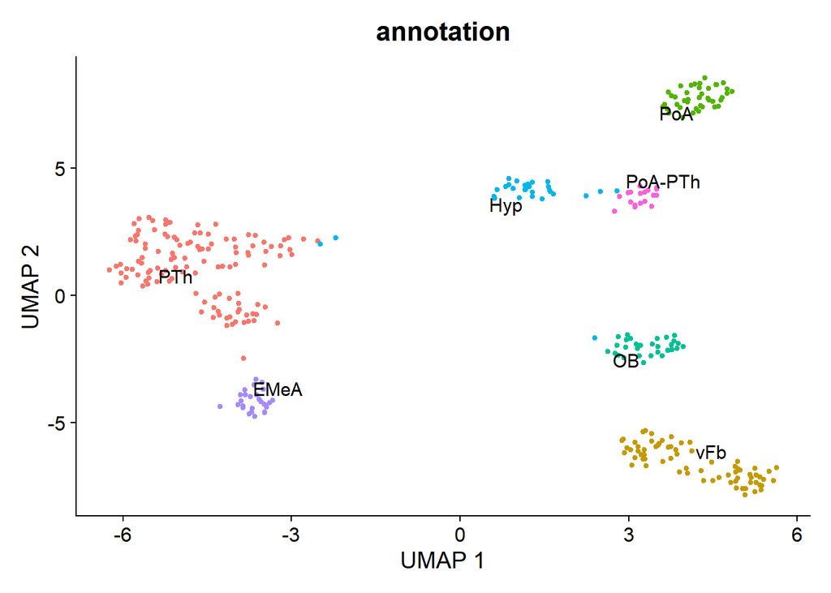

```r
# Generate UMAP visualization of annotated clusters for Figure 1E
IntegDA_DimPlot <- DimPlot(merged_seurat_annot, pt.size = 1, label = T, repel = T, reduction="umap.harmony", group.by = "annotation") +
  NoLegend() +
  labs(x = "UMAP 1", y = "UMAP 2") +
    theme(
        plot.title = element_text(size = 16, face = "bold"))

IntegDA_DimPlot
```

```r
ggsave("Script6_Fig1_PandOwn_DimPlot.svg", plot = IntegDA_DimPlot, path = "Figures/Figure1_GeneralDataset/", width = 5, height = 4)
```

## 8.2 Unintegrated vs Integrated DimPlot

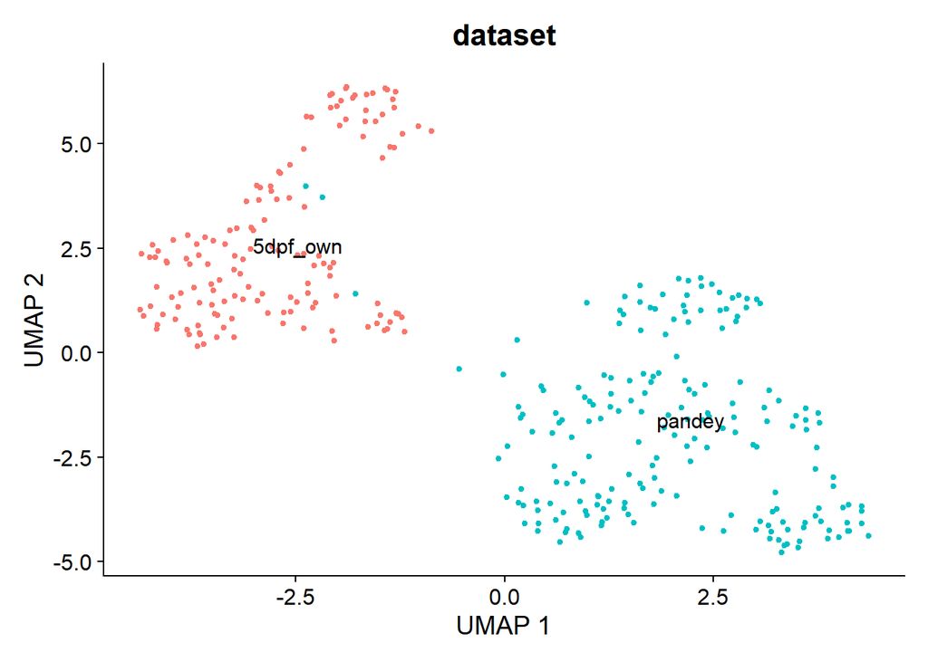

```r
# Generate UMAP visualization of unintegrated and integrated reduction split by dataset for Figure S2E.
IntegDA_DimPlot_split_uninteg <- DimPlot(merged_seurat_annot, pt.size = 1, label = T, repel = T, group.by = "dataset") +
  NoLegend() +
  labs(x = "UMAP 1", y = "UMAP 2") +
    theme(
        plot.title = element_text(size = 16, face = "bold"),
    )

ggsave("Script6_FigS_PandOwn_DimPlot_split_uninteg.svg", plot = IntegDA_DimPlot_split_uninteg, path = "Figures/Figure1_GeneralDataset/", width = 5, height = 4)

IntegDA_DimPlot_split_harminteg <- DimPlot(merged_seurat_annot, pt.size = 1, label = T, repel = T, group.by = "dataset", reduction = "umap.harmony") +
  NoLegend() +
  labs(x = "UMAP 1", y = "UMAP 2") +
    theme(
        plot.title = element_text(size = 16, face = "bold"),
    )

ggsave("Script6_FigS_PandOwn_DimPlot_split_harminteg.svg", plot = IntegDA_DimPlot_split_harminteg, path = "Figures/Figure1_GeneralDataset/", width = 5, height = 4)

print(IntegDA_DimPlot_split_uninteg)
```

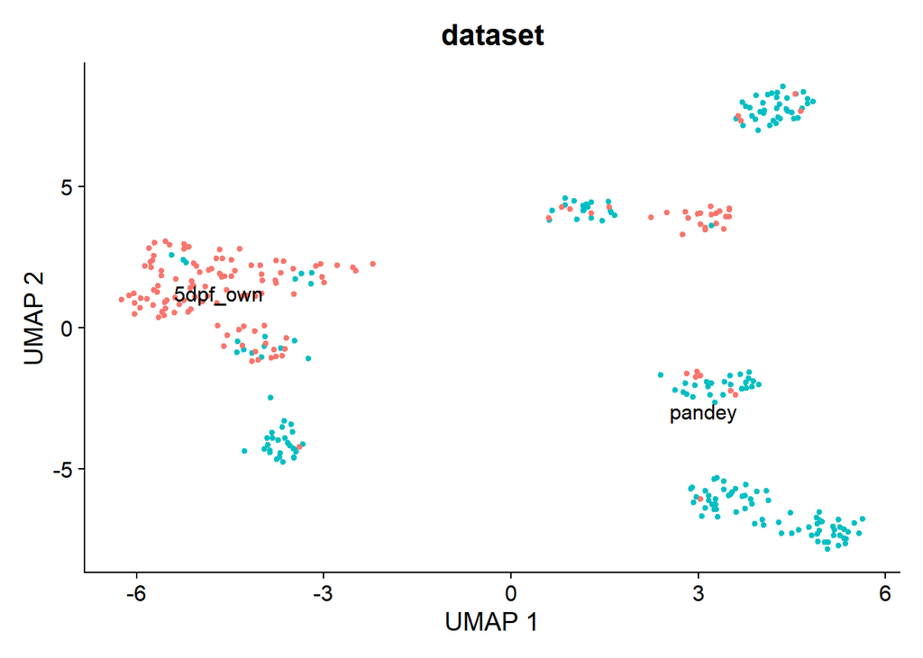

```r
print(IntegDA_DimPlot_split_harminteg)
```

## 8.3 Feature plots for neurotransmitter

```
## [1] "th"
```

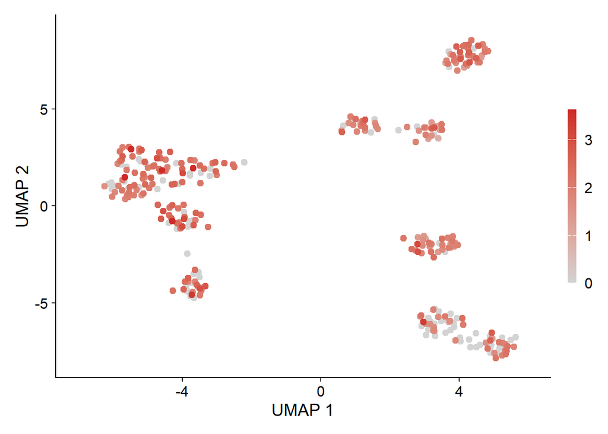

```
## [1] "slc6a2"
```

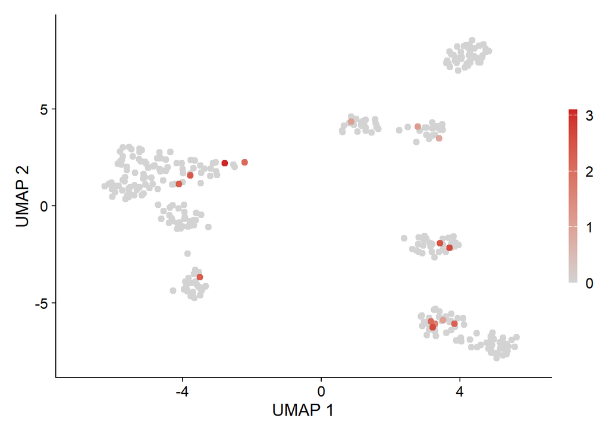

```
## [1] "slc18a2"
```

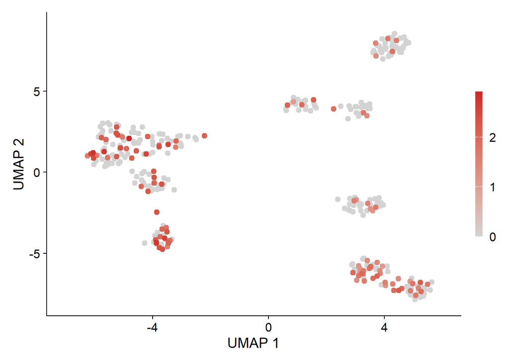

```
## [1] "ddc"
```

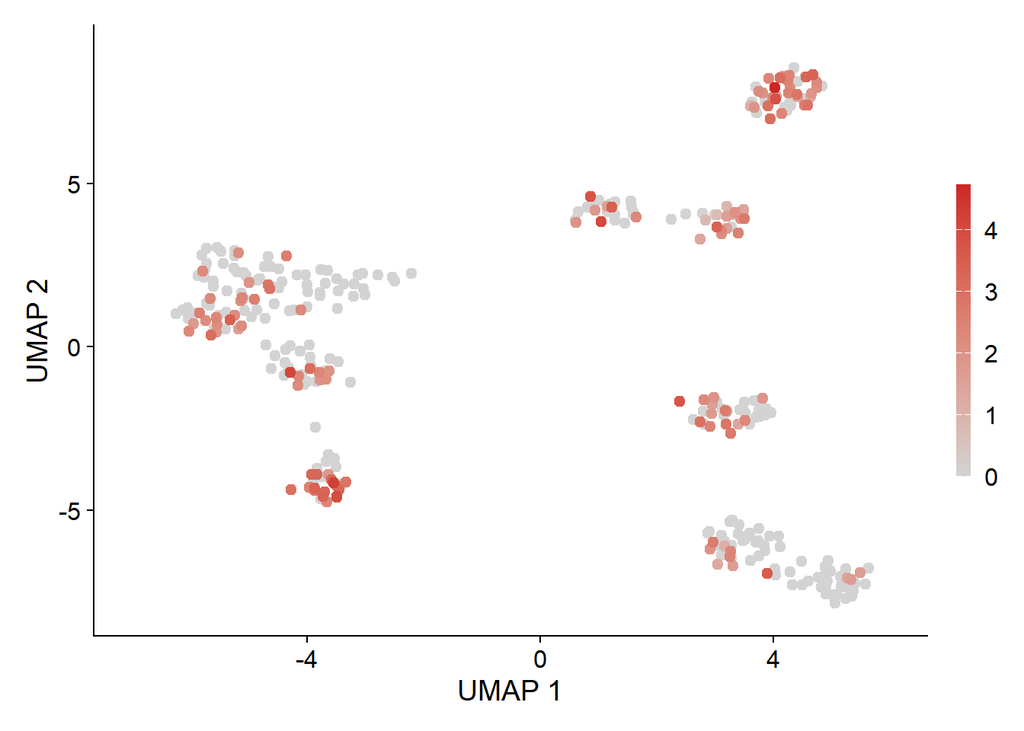

```
## [1] "dbh"
```

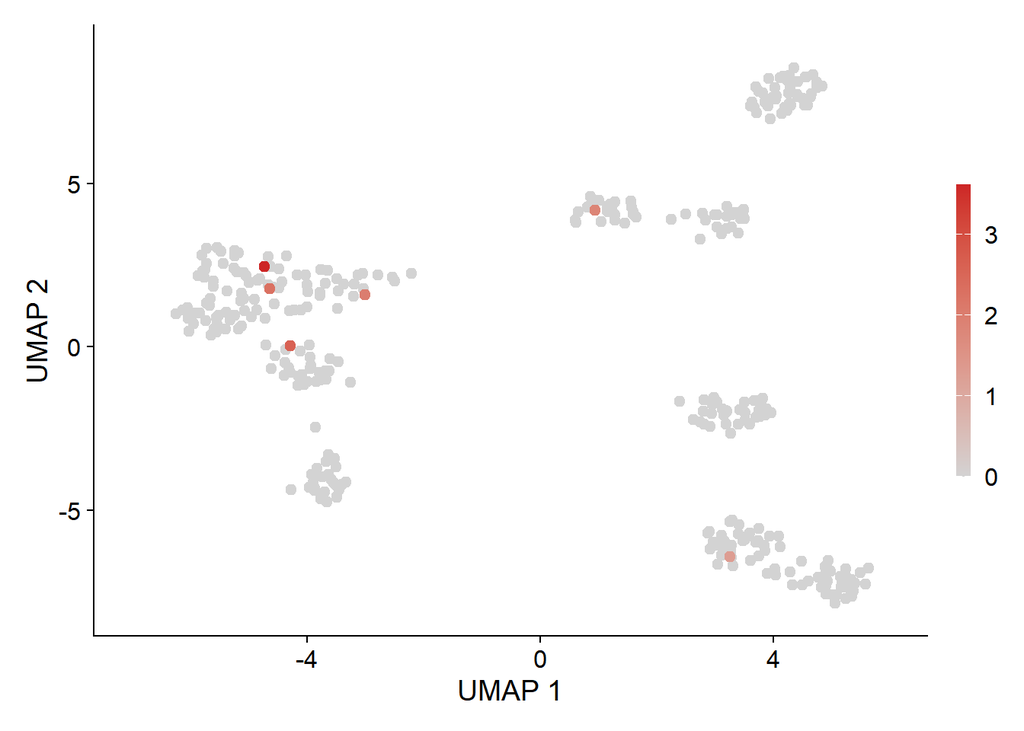

```
## [1] "slc6a3"
```

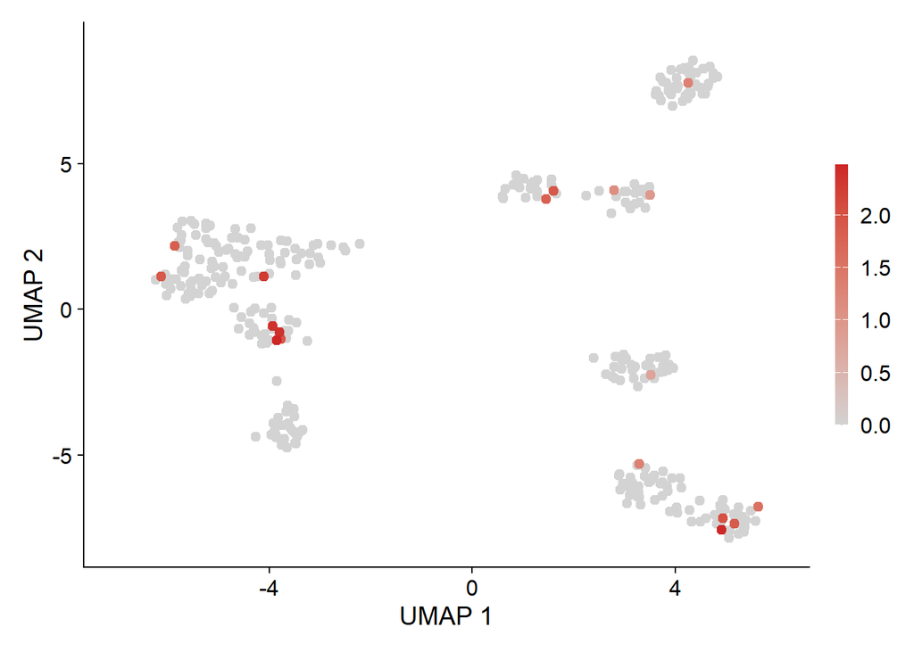

```
## [1] "th2"
```

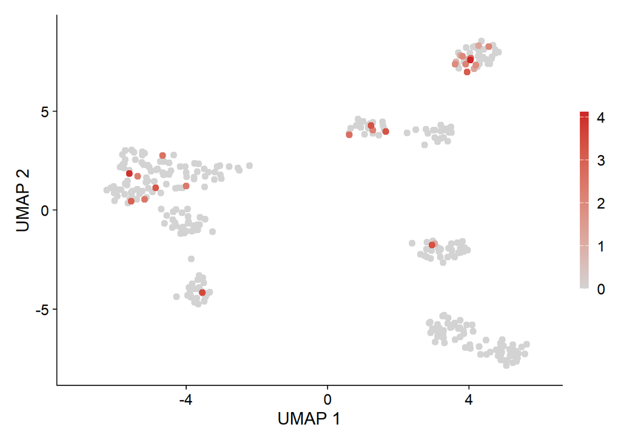

```
## [1] "slc17a6a"
```

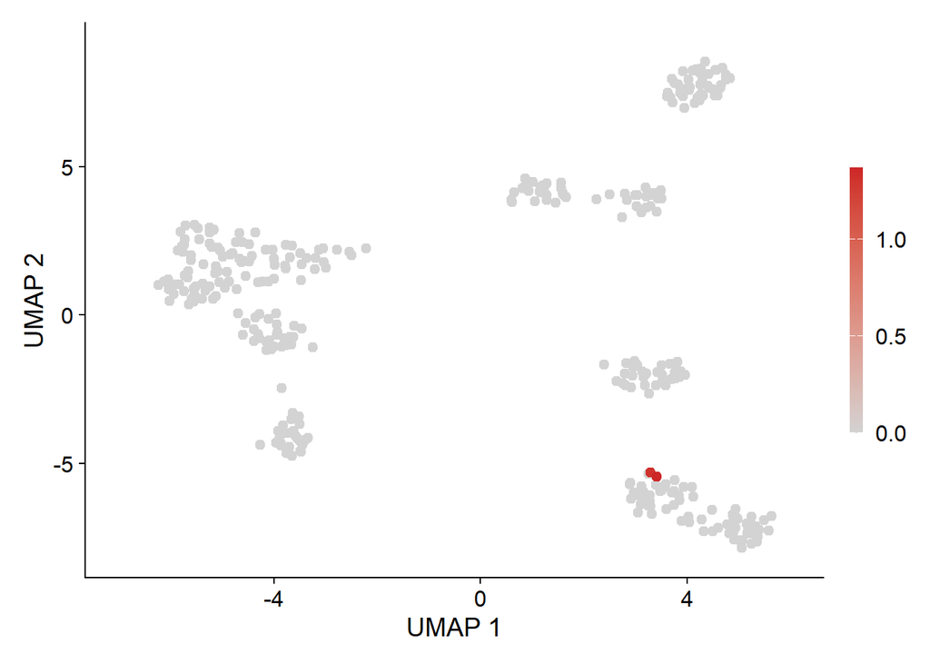

```
## [1] "slc17a6b"
```

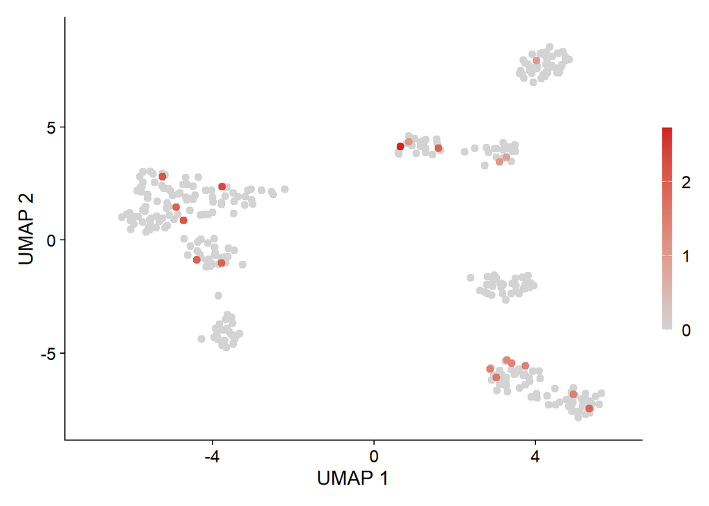

```
## [1] "gad1a"
```

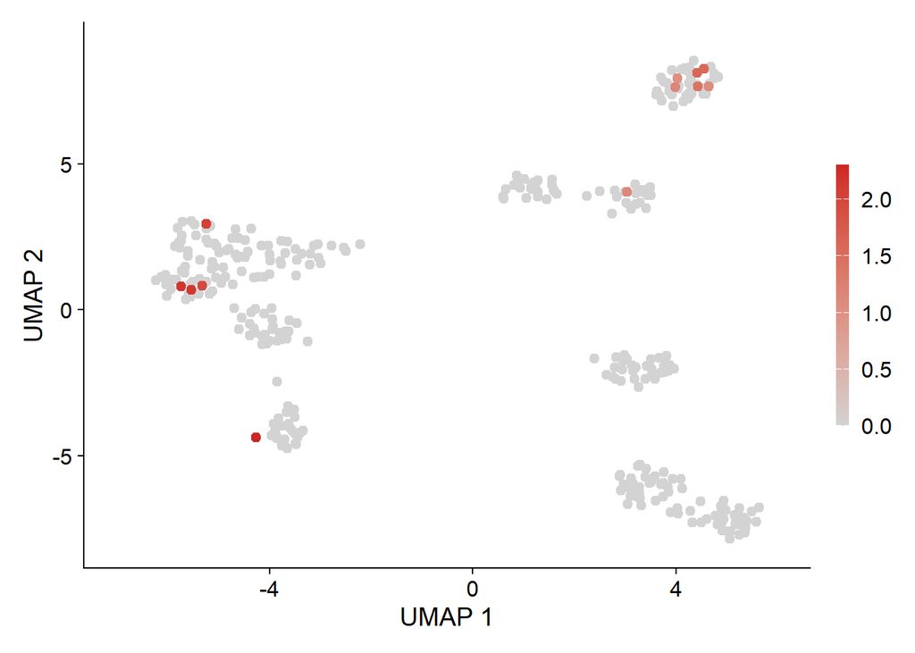

```
## [1] "gad1b"
```

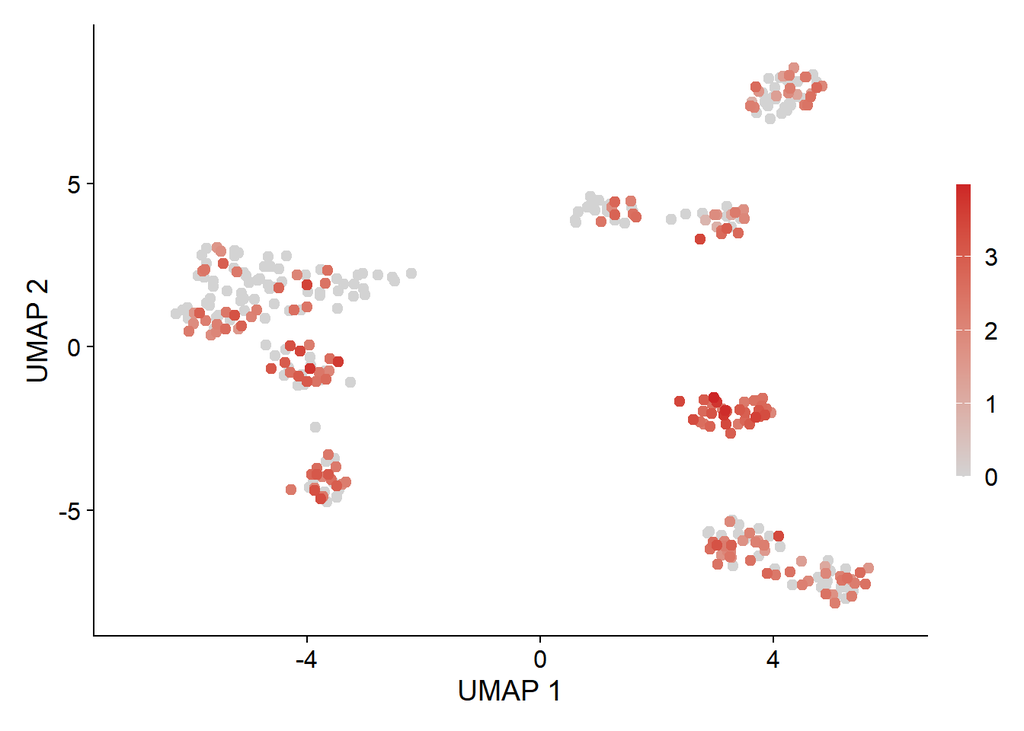

```
## [1] "gad2"
```

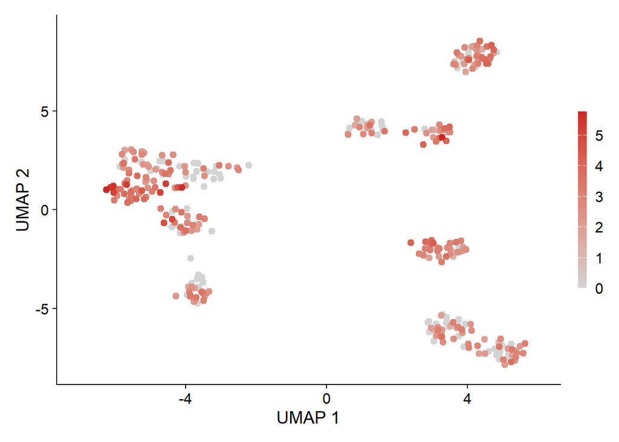

```
## [1] "cpne4a"
```

[2 more figures not shown]

```r
# Generate UMAP  plots showing expression (NormalizeData normalized data slot)  of neurotransmitter markers and additional genes used in Figure 1F and Figure S2F-K
genes <- c("th", "slc6a2", "slc18a2", "ddc", "dbh", "slc6a3", "th2", "slc17a6a", "slc17a6b", "gad1a", "gad1b", "gad2", "cpne4a", "synpr")

 for (gene in genes) {
  plot <- FeaturePlot(merged_seurat_annot, gene, pt.size = 2, order = T,  reduction="umap.harmony") +
    scale_colour_gradient(low="lightgrey", high="#cd2626") +
    labs(x = "UMAP 1", y = "UMAP 2", title = NULL) +
    guides(color = guide_colorbar(barwidth = 0.5, barheight = 10))
    plot_name <- paste("Script6_Fig1_PandOwn_CA-markers_Plots", gene, "_reds.svg")
    print(gene)
    print(plot)
    ggsave(plot_name, plot = plot, path = "Figures/Figure1_GeneralDataset/",
           width = 5, height = 4)

 }
```

# 9. For figure 6

- We assessed the potential of the CA clusters to produce or receive specific neurotransmitter and neuropeptide types based on their expression of marker genes assosiated with the synthesis/release of neurotransmitter, genes encoding neuropeptides or genes encoding receptors for the resprective signaling types.
- Marker lists used can be also found in Table S6b and Table S6I. The neurotransmitter marker genes derive from a previously published list compiled by Martin and colleagues and were extended by NA synthesis and release markers as well as NA receptor encoding genes (Martin et al., 2022; DOI: 10.3389/fnmol.2022.818007). The assessed neuropeptides were selected based on entries in the HGNC database (https://www.genenames.org/data/genegroup/#!/group/1902, February 2025) and the homologs of the respective neuropeptide encoding genes were manually compiled for zebrafish
- The plot generated in this code is part of Figure 6A and B. The exported xlsx files are the basis of Table S6F-H and Table S6M-O.

## 9.1 Neurotransmitter Analysis

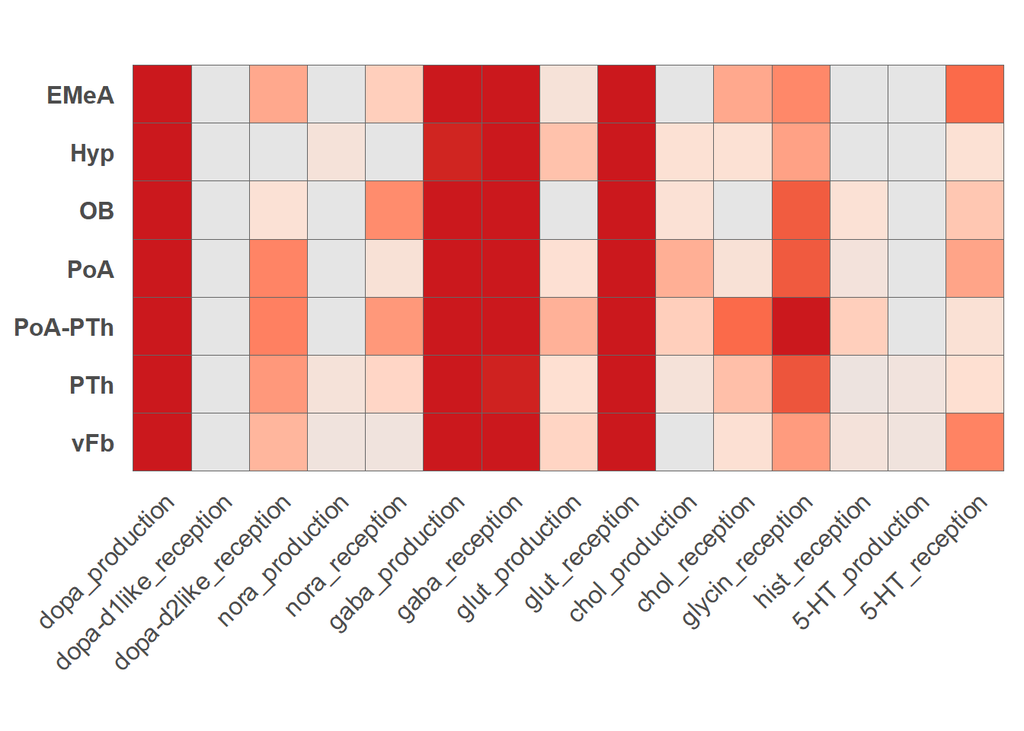

```r
seurat_object_to_analyse <- merged_seurat_annot

# Minimum number of expressed marker genes required for assignment to a specific signaling type
expression_threshold <- 0

# Extract annotated cell clusters
cell_clusters <- as.data.frame(seurat_object_to_analyse$annotation)

# Load t he neurotransmitter/neuropeptide marker gene lists that contain the genes associated with transmitter production and reception
gene_lists <- read.csv(file = "Resources/neurotransmitter_marker.csv", sep=";", skipNul = T, check.names = F)

# Get the raw count expression matrix from RNA assay
expr_matrix <- GetAssayData(seurat_object_to_analyse, assay = "RNA", slot = "count")


# Select marker genes present in the dataset and extract their expression values
all_marker_genes <- unname(unlist(gene_lists))
all_marker_genes <- all_marker_genes[all_marker_genes != ""]
valid_genes <- intersect(all_marker_genes, rownames(expr_matrix))
expr_matrix_relevant_genes <- expr_matrix[valid_genes, ]
expr_matrix_relevant_genes_cells <- t(as.data.frame(expr_matrix_relevant_genes))



# Calculate the average normalized expression for the marker genes per cluster for data export later
expr_matrix_relevant_genes_clusters <- AverageExpression(
  seurat_object_to_analyse,
  assays   = "RNA",
  slot     = "data",
  features = valid_genes,
  group.by = "annotation",
  verbose  = FALSE
)
expr_matrix_relevant_genes_clusters <- as.data.frame(expr_matrix_relevant_genes_clusters)

expr_matrix_relevant_genes_clusters <- expr_matrix_relevant_genes_clusters[match(valid_genes, rownames(expr_matrix_relevant_genes_clusters)), , drop = FALSE]

expr_matrix_relevant_genes_clusters <- t(expr_matrix_relevant_genes_clusters)

################################################################################
# Assigning neurotransmitter/neuropeptide production and reception states
# For each signaling type cells are classified as as producing  or receiving based on expression of at least one marker gene.
################################################################################

# Define neurotransmitters/neuropeptide groups
all_neurotransmitters <- unique(sub("_out$|_in$", "", colnames(gene_lists)))

# Initialize empty matrices for assigning binary values for production and reception
production_matrix <- matrix(0, nrow = ncol(expr_matrix), ncol = length(all_neurotransmitters))
reception_matrix <- matrix(0, nrow = ncol(expr_matrix), ncol = length(all_neurotransmitters))

# Set cell names as row names for both matrices
rownames(production_matrix) <- colnames(expr_matrix)
rownames(reception_matrix) <- colnames(expr_matrix)

# Set neurotransmitters as column names
colnames(production_matrix) <- all_neurotransmitters
colnames(reception_matrix) <- all_neurotransmitters

# Track processed neurotransmitters
processed_neurotransmitters <- c()

# Loop through neurotransmitter/neuropeptide groups and identify producing/receiving cells
for (gene_group_name in all_neurotransmitters) {

    # Identify production marker genes
  production_column <- paste0(gene_group_name, "_out")
  if (production_column %in% colnames(gene_lists)) {
    production_markers <- gene_lists[[production_column]][gene_lists[[production_column]] %in% rownames(expr_matrix)]
  } else {
    production_markers <- NULL
  }

  # Identify reception marker genes
  reception_column <- paste0(gene_group_name, "_in")
  if (reception_column %in% colnames(gene_lists)) {
    reception_markers <- gene_lists[[reception_column]][gene_lists[[reception_column]] %in% rownames(expr_matrix)]
  } else {
    reception_markers <- NULL
  }

  # Assign cells expressing production or reception markers
  if (!is.null(production_markers) && length(production_markers) > 0) {
    production_cells <- colSums(expr_matrix[production_markers, , drop = FALSE] > expression_threshold) > 0
  } else {
    production_cells <- rep(FALSE, ncol(expr_matrix))  # Ensure 0 for all cells
  }

  if (!is.null(reception_markers) && length(reception_markers) > 0) {
    reception_cells <- colSums(expr_matrix[reception_markers, , drop = FALSE] > expression_threshold) > 0
  } else {
    reception_cells <- rep(FALSE, ncol(expr_matrix))  # Ensure 0 for all cells
  }
  # Identify dbh_cells
  dbh_cells <- expr_matrix["dbh", ] > expression_threshold

  # Separate DA and NA cells based on dbh expression to avoid assigning NA cells as DA due to shared markers
  if (gene_group_name == "dopa") {
    production_cells <- production_cells & !dbh_cells
    } else if (gene_group_name == "nora") {
      dbh_cells <- expr_matrix["dbh", ] > expression_threshold
      production_cells <- dbh_cells & production_cells
      }

   # Store assignments in matrices and Seurat metadata
  production_matrix[, gene_group_name] <- as.numeric(production_cells)
  reception_matrix[, gene_group_name] <- as.numeric(reception_cells)

  # Store the classifications in Seurat object metadata
  seurat_object_to_analyse[[paste0(gene_group_name, "_production")]] <- as.numeric(production_cells)
  seurat_object_to_analyse[[paste0(gene_group_name, "_reception")]] <- as.numeric(reception_cells)

  # Mark this neurotransmitter as processed
  processed_neurotransmitters <- c(processed_neurotransmitters, gene_group_name)
}

# Ensure all neurotransmitters are included in metadata, even if missing markers
for (gene_group_name in all_neurotransmitters) {
  if (!(gene_group_name %in% processed_neurotransmitters)) {
    seurat_object_to_analyse[[paste0(gene_group_name, "_production")]] <- 0
    seurat_object_to_analyse[[paste0(gene_group_name, "_reception")]] <- 0
    production_matrix[, gene_group_name] <- 0
    reception_matrix[, gene_group_name] <- 0
  }
}

###################################################################################
# Calculate fraction of cells per cluster expressing neurotransmitter markers
###################################################################################

# Threshold for visualization: only show transmitter/receptor groups that are expressed in at least 10% of cells in one cluster
threshold <- 0.1


# Get cluster identities from your Seurat object to include in the plot
clusters <- rev(levels(seurat_object_to_analyse@active.ident))
clusters <- str_sort(clusters, decreasing = T)

# Initialize matrix to store the fraction of cells assigned to each neurotransmitter production and reception category per cluster
genegroup_Fraction_matrix <- matrix(0, nrow = length(clusters), ncol = length(colnames(gene_lists)))
rownames(genegroup_Fraction_matrix) <- clusters

# Rename columns to include both 'production' and 'reception' labels for each neurotransmitter
col_names <- colnames(gene_lists)
col_names <- str_replace(col_names, "_out", "_production")
col_names <- str_replace(col_names, "_in", "_reception")
colnames(genegroup_Fraction_matrix) <- col_names

# Loop to calculate the fraction of producing and receiving cells for each neurotransmitter within every annotated cluster
for (cluster in clusters) {
  # Select cells belonging to the current calculated cluster
  cluster_cells <- WhichCells(seurat_object_to_analyse, idents = cluster)
    for (name in colnames(gene_lists)) {
    # Strip the "_out" for production and "_in" for reception when accessing metadata
    name <- sub("_out$|_in$", "", name)

    # Define metadata column names for production and reception
    production_colname <- paste0(name, "_production")
    reception_colname <- paste0(name, "_reception")

    # Try to extract production data, otherwise return a vector of zeros
    production_cells <- try(seurat_object_to_analyse@meta.data[cluster_cells, production_colname], silent = TRUE)
    if (inherits(production_cells, "try-error")) {
      production_cells <- rep(0, length(cluster_cells))
    }

    # Try to extract reception data, otherwise return a vector of zeros
    reception_cells <- try(seurat_object_to_analyse@meta.data[cluster_cells, reception_colname], silent = TRUE)
    if (inherits(reception_cells, "try-error")) {
      reception_cells <- rep(0, length(cluster_cells))
    }

    # Calculate fraction of producing and receiving cells
    production_Fraction <- sum(production_cells) / length(cluster_cells)
    reception_Fraction <- sum(reception_cells) / length(cluster_cells)

    # Store calculated fractions
    try(genegroup_Fraction_matrix[cluster, paste(name, "production", sep = "_")] <- production_Fraction, silent = TRUE)
    try(genegroup_Fraction_matrix[cluster, paste(name, "reception", sep = "_")] <- reception_Fraction, silent = TRUE)
  }
}

###################################################################################
# Visualization and data export
###################################################################################

# Reshape the matrix for ggplot2
Fraction_df <- reshape2::melt(genegroup_Fraction_matrix)

# Change Fraction df colnames
colnames(Fraction_df) <- c("Cluster", "Neurotransmitter_Type", "Fraction")



# Identify neurotransmitter types where any cluster exceeds the threshold
valid_types <- Fraction_df %>%
  group_by(Neurotransmitter_Type) %>%
  dplyr::filter(any(Fraction >= threshold)) %>%
  pull(Neurotransmitter_Type) %>%
  unique()

# "Manual" override to include the signaling types in the plots that came up in either the analysis of the clusters of Figure 1c or 1e
# Neurotransmitter
valid_types <- list(
  "5-HT_production",
  "5-HT_reception",
  "chol_production",
  "chol_reception",
  "dopa_production",
  "dopa-d1like_reception",
  "dopa-d2like_reception",
  "gaba_production",
  "gaba_reception",
  "glut_production",
  "glut_reception",
  "glycin_reception",
  "hist_reception",
  "nora_production",
  "nora_reception"
  )

# All transmitter/peptide Fractions per cluster
Fraction_df_all <- Fraction_df

# Filter data: for visualization Keep all clusters for these neurotransmitters
Fraction_df <- Fraction_df %>%
  dplyr::filter(Neurotransmitter_Type %in% valid_types)



plot <- ggplot(Fraction_df, aes(x = Neurotransmitter_Type, y = Cluster, fill = Fraction)) +
  geom_tile(color = "black") +
  #geom_text(aes(label = round(percentage, 2)),
            #color = "black") +
          scale_fill_gradientn(
             colours = c("grey90","#fee0d2","#fb6a4a","#cb181d"),
            trans = "sqrt",
            limits = c(0, 0.75),#
            oob = scales::squish) +
          labs(title = NULL, x = NULL, y = NULL, fill = "Fraction of cells") +
          theme_minimal(base_size = 14) +
          theme(axis.text.x = element_text(angle = 45, hjust = 1, vjust = 1, size = 12),
                axis.text.y = element_text(size = 12, face = "bold",),
                plot.title = element_text(hjust = 0.5, face = "bold", size = 16),
                legend.position = "right",
                panel.grid.major = element_blank(),
                panel.grid.minor = element_blank()) +
                coord_fixed() +
                geom_tile(color = "grey40", linewidth = 0.25)+
                NoLegend()

ggsave(paste("Script6_Fig6_Zebrafish_Integ_Neurotransmitters_Sqrt_", Sys.Date(), ".svg"), plot = plot, path = "Figures/Figure6_TransmitterPeptideCodes/", width = 16, height = 8, bg = "white")

# Generate and save legend
legend_plot <- cowplot::ggdraw(get_legend(
  ggplot(Fraction_df, aes(x = Neurotransmitter_Type, y = Cluster, fill = Fraction)) +
    geom_tile() +
    scale_fill_gradientn(
  colours = c("grey90", "#fee0d2", "#fb6a4a", "#cb181d"),
  trans  = "sqrt",
  limits = c(0, 0.75),
  oob    = scales::squish,
  breaks = c(0, 0.05, 0.25, 0.50, 0.75),
  labels = scales::label_percent(accuracy = 1)
) +
    theme_minimal() +
    theme(legend.position = "right")
))

ggsave("Figures/Figure6_TransmitterPeptideCodes/Script6_Fig6_Zebrafish_Integ_Neurotransmitters_Sqrt_Legend.svg", plot = legend_plot, width = 2, height = 4, bg = "white")

print(plot)
```

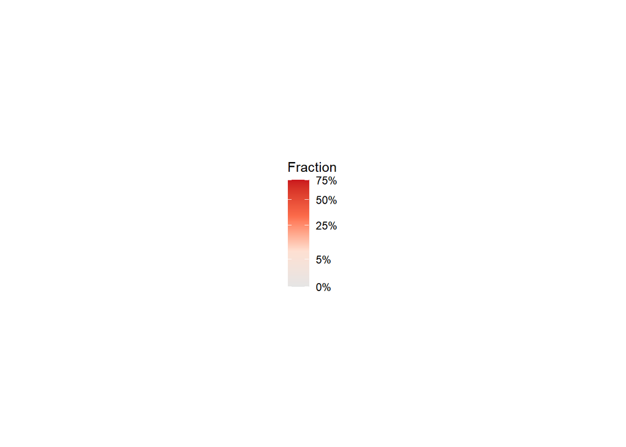

```r
print(legend_plot)
```

```r
# Save numerical data of the analysis
dataset_names <- list("used_markers_genes" = gene_lists, "raw_counts_cells" = expr_matrix_relevant_genes_cells, "assigned_clusters" = cell_clusters, "avg_norm_counts_cluster" = expr_matrix_relevant_genes_clusters, "fraction_per_cluster" = Fraction_df_all )
openxlsx::write.xlsx(dataset_names, file = "Figures/Figure6_TransmitterPeptideCodes/Script6_Fig6_Zebrafish_Integ_Neurotransmitter.xlsx", rowNames = TRUE)
```

## 9.2 Neuropeptide Analysis

```r
seurat_object_to_analyse <- merged_seurat_annot

# Minimum number of expressed marker genes required for assignment to a specific signaling type
expression_threshold <- 0

# Extract annotated cell clusters
cell_clusters <- as.data.frame(seurat_object_to_analyse$annotation)

# Load t he neurotransmitter/neuropeptide marker gene lists that contain the genes associated with transmitter production and reception
gene_lists <- read.csv(file = "Resources/neuropeptides_marker.csv", sep=";", skipNul = T, check.names = F)

# Get the raw count expression matrix from RNA assay
expr_matrix <- GetAssayData(seurat_object_to_analyse, assay = "RNA", slot = "count")


# Select marker genes present in the dataset and extract their expression values
all_marker_genes <- unname(unlist(gene_lists))
all_marker_genes <- all_marker_genes[all_marker_genes != ""]
valid_genes <- intersect(all_marker_genes, rownames(expr_matrix))
expr_matrix_relevant_genes <- expr_matrix[valid_genes, ]
expr_matrix_relevant_genes_cells <- t(as.data.frame(expr_matrix_relevant_genes))



# Calculate the average normalized expression for the marker genes per cluster for data export later
expr_matrix_relevant_genes_clusters <- AverageExpression(
  seurat_object_to_analyse,
  assays   = "RNA",
  slot     = "data",
  features = valid_genes,
  group.by = "annotation",
  verbose  = FALSE
)
expr_matrix_relevant_genes_clusters <- as.data.frame(expr_matrix_relevant_genes_clusters)

expr_matrix_relevant_genes_clusters <- expr_matrix_relevant_genes_clusters[match(valid_genes, rownames(expr_matrix_relevant_genes_clusters)), , drop = FALSE]

expr_matrix_relevant_genes_clusters <- t(expr_matrix_relevant_genes_clusters)

################################################################################
# Assigning neurotransmitter/neuropeptide production and reception states
# For each signaling type cells are classified as as producing  or receiving based on expression of at least one marker gene.
################################################################################

# Define neurotransmitters/neuropeptide groups
all_neurotransmitters <- unique(sub("_out$|_in$", "", colnames(gene_lists)))

# Initialize empty matrices for assigning binary values for production and reception
production_matrix <- matrix(0, nrow = ncol(expr_matrix), ncol = length(all_neurotransmitters))
reception_matrix <- matrix(0, nrow = ncol(expr_matrix), ncol = length(all_neurotransmitters))

# Set cell names as row names for both matrices
rownames(production_matrix) <- colnames(expr_matrix)
rownames(reception_matrix) <- colnames(expr_matrix)

# Set neurotransmitters as column names
colnames(production_matrix) <- all_neurotransmitters
colnames(reception_matrix) <- all_neurotransmitters

# Track processed neurotransmitters
processed_neurotransmitters <- c()

# Loop through neurotransmitter/neuropeptide groups and identify producing/receiving cells
for (gene_group_name in all_neurotransmitters) {

    # Identify production marker genes
  production_column <- paste0(gene_group_name, "_out")
  if (production_column %in% colnames(gene_lists)) {
    production_markers <- gene_lists[[production_column]][gene_lists[[production_column]] %in% rownames(expr_matrix)]
  } else {
    production_markers <- NULL
  }

  # Identify reception marker genes
  reception_column <- paste0(gene_group_name, "_in")
  if (reception_column %in% colnames(gene_lists)) {
    reception_markers <- gene_lists[[reception_column]][gene_lists[[reception_column]] %in% rownames(expr_matrix)]
  } else {
    reception_markers <- NULL
  }

  # Assign cells expressing production or reception markers
  if (!is.null(production_markers) && length(production_markers) > 0) {
    production_cells <- colSums(expr_matrix[production_markers, , drop = FALSE] > expression_threshold) > 0
  } else {
    production_cells <- rep(FALSE, ncol(expr_matrix))  # Ensure 0 for all cells
  }

  if (!is.null(reception_markers) && length(reception_markers) > 0) {
    reception_cells <- colSums(expr_matrix[reception_markers, , drop = FALSE] > expression_threshold) > 0
  } else {
    reception_cells <- rep(FALSE, ncol(expr_matrix))  # Ensure 0 for all cells
  }
  # Identify dbh_cells
  dbh_cells <- expr_matrix["dbh", ] > expression_threshold

  # Separate DA and NA cells based on dbh expression to avoid assigning NA cells as DA due to shared markers
  if (gene_group_name == "dopa") {
    production_cells <- production_cells & !dbh_cells
    } else if (gene_group_name == "nora") {
      dbh_cells <- expr_matrix["dbh", ] > expression_threshold
      production_cells <- dbh_cells & production_cells
      }

   # Store assignments in matrices and Seurat metadata
  production_matrix[, gene_group_name] <- as.numeric(production_cells)
  reception_matrix[, gene_group_name] <- as.numeric(reception_cells)

  # Store the classifications in Seurat object metadata
  seurat_object_to_analyse[[paste0(gene_group_name, "_production")]] <- as.numeric(production_cells)
  seurat_object_to_analyse[[paste0(gene_group_name, "_reception")]] <- as.numeric(reception_cells)

  # Mark this neurotransmitter as processed
  processed_neurotransmitters <- c(processed_neurotransmitters, gene_group_name)
}

# Ensure all neurotransmitters are included in metadata, even if missing markers
for (gene_group_name in all_neurotransmitters) {
  if (!(gene_group_name %in% processed_neurotransmitters)) {
    seurat_object_to_analyse[[paste0(gene_group_name, "_production")]] <- 0
    seurat_object_to_analyse[[paste0(gene_group_name, "_reception")]] <- 0
    production_matrix[, gene_group_name] <- 0
    reception_matrix[, gene_group_name] <- 0
  }
}

###################################################################################
# Calculate fraction of cells per cluster expressing neurotransmitter markers
###################################################################################

# Threshold for visualization: only show transmitter/receptor groups that are expressed in at least 10% of cells in one cluster
threshold <- 0.1
```

```r
# Get cluster identities from your Seurat object to include in the plot
clusters <- rev(levels(seurat_object_to_analyse@active.ident))
clusters <- str_sort(clusters, decreasing = T)

# Initialize matrix to store the fraction of cells assigned to each neurotransmitter production and reception category per cluster
genegroup_Fraction_matrix <- matrix(0, nrow = length(clusters), ncol = length(colnames(gene_lists)))
rownames(genegroup_Fraction_matrix) <- clusters

# Rename columns to include both 'production' and 'reception' labels for each neurotransmitter
col_names <- colnames(gene_lists)
col_names <- str_replace(col_names, "_out", "_production")
col_names <- str_replace(col_names, "_in", "_reception")
colnames(genegroup_Fraction_matrix) <- col_names

# Loop to calculate the fraction of producing and receiving cells for each neurotransmitter within every annotated cluster
for (cluster in clusters) {
  # Select cells belonging to the current calculated cluster
  cluster_cells <- WhichCells(seurat_object_to_analyse, idents = cluster)
    for (name in colnames(gene_lists)) {
    # Strip the "_out" for production and "_in" for reception when accessing metadata
    name <- sub("_out$|_in$", "", name)

    # Define metadata column names for production and reception
    production_colname <- paste0(name, "_production")
    reception_colname <- paste0(name, "_reception")

    # Try to extract production data, otherwise return a vector of zeros
    production_cells <- try(seurat_object_to_analyse@meta.data[cluster_cells, production_colname], silent = TRUE)
    if (inherits(production_cells, "try-error")) {
      production_cells <- rep(0, length(cluster_cells))
    }

    # Try to extract reception data, otherwise return a vector of zeros
    reception_cells <- try(seurat_object_to_analyse@meta.data[cluster_cells, reception_colname], silent = TRUE)
    if (inherits(reception_cells, "try-error")) {
      reception_cells <- rep(0, length(cluster_cells))
    }

    # Calculate fraction of producing and receiving cells
    production_Fraction <- sum(production_cells) / length(cluster_cells)
    reception_Fraction <- sum(reception_cells) / length(cluster_cells)

    # Store calculated fractions
    try(genegroup_Fraction_matrix[cluster, paste(name, "production", sep = "_")] <- production_Fraction, silent = TRUE)
    try(genegroup_Fraction_matrix[cluster, paste(name, "reception", sep = "_")] <- reception_Fraction, silent = TRUE)
  }
}

###################################################################################
# Visualization and data export
###################################################################################

# Reshape the matrix for ggplot2
Fraction_df <- reshape2::melt(genegroup_Fraction_matrix)

# Change Fraction df colnames
colnames(Fraction_df) <- c("Cluster", "Neurotransmitter_Type", "Fraction")



# Identify neurotransmitter types where any cluster exceeds the threshold
valid_types <- Fraction_df %>%
  group_by(Neurotransmitter_Type) %>%
  dplyr::filter(any(Fraction >= threshold)) %>%
  pull(Neurotransmitter_Type) %>%
  unique()

# "Manual" override to include the signaling types in the plots that came up in either the analysis of the clusters of Figure 1c or 1e
# Neurotransmitter
# Neuropeptides
valid_types <- list(
  "Adcyap_production",
  "Adcyap_reception",
  "Adm_reception",
  "Agrp_reception",
  "Apln_production",
  "Calca_production",
  "Calca_reception",
  "Cb_reception",
  "Ccka_production",
  "Chga_production",
  "Crh_reception",
  "Galn_production",
  "Galn_reception",
  "Ghrh_production",
  "Grp_production",
  "Grp_reception",
  "Igf_production",
  "Igf_reception",
  "Ins_reception",
  "Kiss_reception",
  "Lep_reception",
  "Mln_reception",
  "Nmb_production",
  "Nmb_reception",
  "Nmu_production",
  "Npb_production",
  "Npp_production",
  "Npp_reception",
  "Npy_production",
  "Npy_reception",
  "Nts_production",
  "Nts_reception",
  "Pdyn_production",
  "Penk_production",
  "Penk_reception",
  "Pnoc_production",
  "Pomc_production",
  "Prl_production",
  "Pyy_production",
  "Sst_production",
  "Sst_production ",
  "Sst_reception",
  "Trh_reception",
  "Uts_production",
  "Vip_reception"
  )

# All transmitter/peptide Fractions per cluster
Fraction_df_all <- Fraction_df

# Filter data: for visualization Keep all clusters for these neurotransmitters
Fraction_df <- Fraction_df %>%
  dplyr::filter(Neurotransmitter_Type %in% valid_types)



plot <- ggplot(Fraction_df, aes(x = Neurotransmitter_Type, y = Cluster, fill = Fraction)) +
  geom_tile(color = "black") +
  #geom_text(aes(label = round(percentage, 2)),
            #color = "black") +
          scale_fill_gradientn(
             colours = c("grey90","#fee0d2","#fb6a4a","#cb181d"),
            trans = "sqrt",
            limits = c(0, 0.75),#
            oob = scales::squish) +
          labs(title = NULL, x = NULL, y = NULL, fill = "Fraction of cells") +
          theme_minimal(base_size = 14) +
          theme(axis.text.x = element_text(angle = 45, hjust = 1, vjust = 1, size = 12),
                axis.text.y = element_text(size = 12, face = "bold",),
                plot.title = element_text(hjust = 0.5, face = "bold", size = 16),
                legend.position = "right",
                panel.grid.major = element_blank(),
                panel.grid.minor = element_blank()) +
                coord_fixed() +
                geom_tile(color = "grey40", linewidth = 0.25)+
                NoLegend()

ggsave(paste("Script6_Fig6_Zebrafish_Integ_Neuropeptides_Sqrt_", Sys.Date(), ".svg"), plot = plot, path = "Figures/Figure6_TransmitterPeptideCodes/", width = 16, height = 8, bg = "white")

# Generate and save legend
legend_plot <- cowplot::ggdraw(get_legend(
  ggplot(Fraction_df, aes(x = Neurotransmitter_Type, y = Cluster, fill = Fraction)) +
    geom_tile() +
    scale_fill_gradientn(
  colours = c("grey90", "#fee0d2", "#fb6a4a", "#cb181d"),
  trans  = "sqrt",
  limits = c(0, 0.75),
  oob    = scales::squish,
  breaks = c(0, 0.05, 0.25, 0.50, 0.75),
  labels = scales::label_percent(accuracy = 1)
) +
    theme_minimal() +
    theme(legend.position = "right")
))
```

[figure not shown]

```r
ggsave("Figures/Figure6_TransmitterPeptideCodes/Script6_Fig6_Zebrafish_Integ_Neuropeptides_Sqrt_Legend.svg", plot = legend_plot, width = 2, height = 4, bg = "white")

print(plot)
```

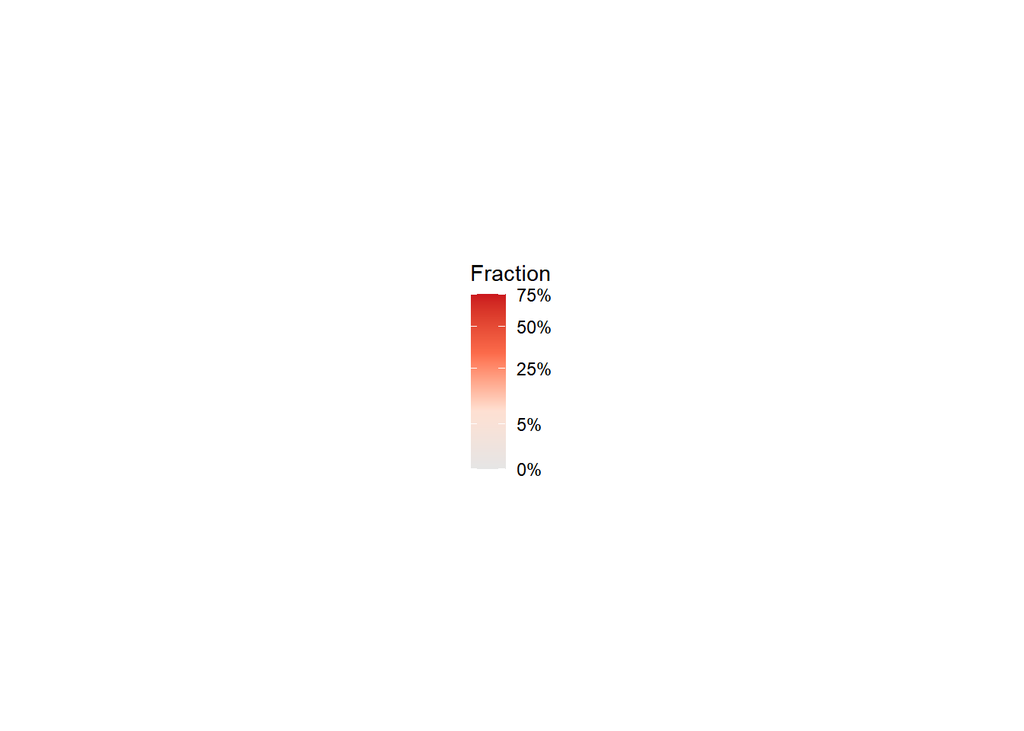

```r
print(legend_plot)
```

```r
# Save numerical data of the analysis
dataset_names <- list("used_markers_genes" = gene_lists, "raw_counts_cells" = expr_matrix_relevant_genes_cells, "assigned_clusters" = cell_clusters, "avg_norm_counts_cluster" = expr_matrix_relevant_genes_clusters, "fraction_per_cluster" = Fraction_df_all )
openxlsx::write.xlsx(dataset_names, file = "Figures/Figure6_TransmitterPeptideCodes/Script6_Fig6_Zebrafish_Integ_Neuropeptides.xlsx", rowNames = TRUE)
```

## 9.3 Average TF counts per cluster

- Get the average normalized expression from the RNA assay of all transcription factors expressed in the CA clusters.
- This is the basis of Table S1F

```r
merged_seurat_annot <- readRDS("RDS_files/Script6_Armbruster2026_integ_annot.rds")


norm_avgcounts_per_cluster <- AverageExpression(
  merged_seurat_annot,
  assays   = "RNA",
  slot     = "data",
  group.by = "annotation",
  verbose  = FALSE,
  features = TFlist$gene
)
```

[output not shown]

[output cut: 57 more lines]

[output not shown]

```r
df_norm_avgcounts_per_cluster <- data.frame(norm_avgcounts_per_cluster)

openxlsx::write.xlsx(df_norm_avgcounts_per_cluster, file ="other_data_tables/Script6_Figure1e_clusters_avgnormalizedTFcounts.xlsx", rowNames=T)
```

```r
# Remove objects to reduce memory usage
rm(list=ls())
gc()
```

```
##           used  (Mb) gc trigger   (Mb)  max used   (Mb)
## Ncells 4145138 221.4    6546024  349.6   6546024  349.6
## Vcells 7623410  58.2  328109738 2503.3 410111205 3129.0
```